# Repeatable Modelling Workflow

Kim Cressman

created 2022-02-08; latest update 2025-11-10

```r
library(readxl)
library(readr)
library(dplyr)
library(tidyr)
library(stringr)
library(ggplot2)
library(patchwork)
library(lmerTest)
library(MuMIn)
library(boot)
library(tibble)

# cost function for sMdAPE (symmetric median absolute percent error)
# works on square-root transformed response variable
cost <- function(obs, expt){
    median(
        abs(
            100 * (obs^2-expt^2) / ((obs^2+expt^2)/2)
        )
    )
}
```

This document pulls together all the model-running and coefficient-presenting code, by using previous scripts as child documents.

# Data Import and Summaries

A few notes.

- NIW collected tank samples from one site and ISCO samples from a different site. Due to their concerns about pooling data from the two sites (they are very different environments), I created a ‘NIW_isco’ reserve ID to differentiate.
- For a similar reason, I created a ‘HEE_w2’ reserve ID for the site where He’eia started getting samples for this project, but the water is so clear that the sensor wasn’t working well. Figured I’d separate it out.
- GRB used 8 different stations throughout. *I did not differentiate.* If models fit poorly for this reserve, this could be a reason.
- PDB used 3 differents stations, and again I did not differentiate.
- I made up a station ID for Sapelo because they did not use a normal SWMP station. I called it ‘sapnawq’ (for ‘N/A’, ha)

**In this file**

- Data will be subsetted to a data frame that does not contain ANY NAs, because model selection is based on models containing exactly the same input data.
- That subset will be saved as an `.Rdata` file for easier import and reuse downstream.
- Some summary statistics for the data that will be used will be generated.

## Data import and export

re-run 12/16/2021 to incorporate new data file sent on 12/15 (GRB ISCO data had been left out of original file)

**update 2/16/2022 to incorporate temperature-corrected RFU** (based on Hannah Ramage’s calculations) into the modeling data frame. The “global” rho is an average of the rho values in all of the temperature-interference trials. The global rho is then inserted into the Watras et al. 2017 Eq. 1:

Temp-corrected-RFU = original-RFU / (1 + global_rho*(temp_reading - 20))

I’m hardcoding in the rhos here because it’s easier than dealing with another file, but am setting up the code to be rerun easily with a different batch of rhos (however they’re read in).

```r
rhos <- c(-0.018449239,
-0.017224308,
-0.006810888,
-0.017013983,
-0.016389726,
-0.016809971,
-0.010759556,
-0.011669893,
-0.006993083,
-0.010889714,
-0.0081596,
-0.002334279
)

global_rho <- mean(rhos)

dat <- read_xlsx(here::here("data", "2021_chla-catalyst_data_all.xlsx"),
                 sheet = "qaqc") %>%
    mutate(extracted = chla_ugl,
           sensor_rfu = chlorophyll_rfu,
           sensor_ugl = chl_fluor,
           month = lubridate::month(datetime_collected),
           season = case_when(month %in% c(12, 1, 2)  ~ "Winter",
                              month %in% c(3, 4, 5)   ~ "Spring",
                              month %in% c(6, 7, 8)   ~ "Summer",
                              month %in% c(9, 10, 11) ~ "Fall")) %>%
    select(reserve = reserve_code,
           station = station_code,
           datetime_collected,
           month,
           season,
           method,
           extracted,
           sensor_rfu,
           temp,
           turb,
           fdom_qsu) %>%
    mutate(station = case_when(reserve == "GND" ~ "gndblwq",
                               reserve == "SAP" ~ "sapnawq",
                               TRUE ~ station),
           reserve = case_when(station == "heew2wq" ~ "HEE_w2",
                               station == "WS" ~ "NIW_isco", # at NIW: OL is tank; WS is ISCO. These should not be pooled.
                               TRUE ~ reserve),
           station = case_when(station == "OL" ~ "niwolwq",
                               station == "WS" ~ "niwwswq",
                               TRUE ~ station)) %>%
    drop_na() %>%
    mutate(across(c(reserve, month, season),
                  as.factor),
           season = forcats::fct_relevel(season, c("Winter", "Spring", "Summer", "Fall")),
           rfu_temp_corrected = sensor_rfu / (1 + global_rho*(temp-20)))

save(dat, file = here::here("data", "subset_no_NA.RData"))
# uncommented and ran the above, 2/16/22

# read back in later with:
# load(here::here("data", "subset_no_NA.RData"))
```

Global rho: -0.01196

Quick gut-check on temp-corrected RFU:

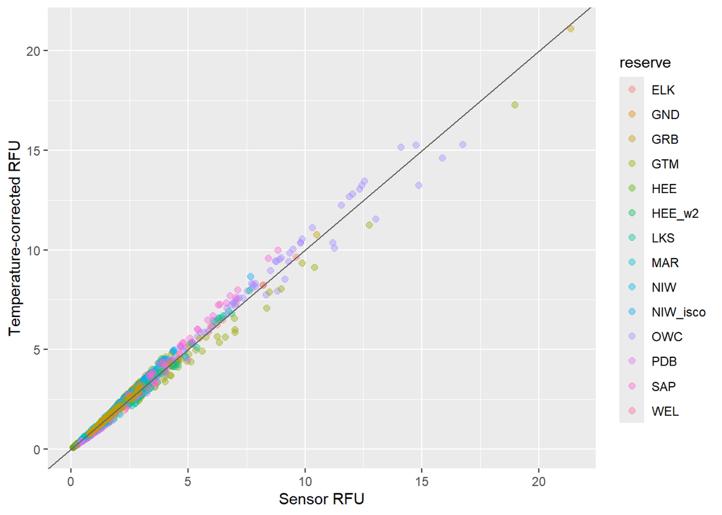

```r
ggplot(dat, aes(x = sensor_rfu, y = rfu_temp_corrected)) +
    geom_point(size = 2, alpha = 0.4, aes(color = reserve)) +
    geom_abline(slope = 1, intercept = 0, color = "gray40") +
    labs(x = "Sensor RFU",
         y = "Temperature-corrected RFU")
```

Points are generally close to the 1:1 line.

## Summary

### General

```r
dat %>% group_by(reserve) %>% count(station) %>% knitr::kable()
```

| reserve | station | n |
| --- | --- | --- |
| ELK | elksmwq | 93 |
| GND | gndblwq | 21 |
| GRB | grbapmwq | 1 |
| GRB | grbapwq | 43 |
| GRB | grbgbewq | 2 |
| GRB | grblrwq | 65 |
| GRB | grborwq | 2 |
| GRB | grbsqwq | 29 |
| GRB | grbulbwq | 1 |
| GTM | gtmpcwq | 175 |
| HEE | heekkwq | 28 |
| HEE_w2 | heew2wq | 4 |
| LKS | lksbawq | 125 |
| MAR | marscwq | 17 |
| NIW | niwolwq | 65 |
| NIW_isco | niwwswq | 72 |
| OWC | owcwmwq | 130 |
| PDB | pdbbywq | 74 |
| PDB | pdbgswq | 8 |
| SAP | sapnawq | 46 |
| WEL | welinwq | 75 |

```r
summary(dat)
```

```
##     reserve      station          datetime_collected
##  GTM    :175   Length:1076        Min.   :2020-11-12 06:50:00.00
##  GRB    :143   Class :character   1st Qu.:2021-04-11 04:36:45.00
##  OWC    :130   Mode  :character   Median :2021-06-16 19:30:00.03
##  LKS    :125                      Mean   :2021-05-29 16:18:07.11
##  ELK    : 93                      3rd Qu.:2021-07-22 18:14:59.99
##  PDB    : 82                      Max.   :2021-10-01 09:50:00.00
##  (Other):328
##      month        season       method            extracted
##  7      :217   Winter:211   Length:1076        Min.   : 0.0037
##  6      :190   Spring:241   Class :character   1st Qu.: 2.8600
##  5      :140   Summer:516   Mode  :character   Median : 6.8848
##  2      :119   Fall  :108                      Mean   :11.6401
##  8      :109                                   3rd Qu.:15.6518
##  9      :103                                   Max.   :92.0100
##  (Other):198
##    sensor_rfu           temp             turb            fdom_qsu
##  Min.   : 0.0700   Min.   : 0.019   Min.   :  0.111   Min.   :  0.5275
##  1st Qu.: 0.9785   1st Qu.:14.741   1st Qu.:  3.518   1st Qu.: 15.4450
##  Median : 1.9900   Median :19.956   Median :  7.300   Median : 57.0141
##  Mean   : 2.5794   Mean   :19.190   Mean   : 11.222   Mean   : 62.6476
##  3rd Qu.: 3.2000   3rd Qu.:25.111   3rd Qu.: 14.012   3rd Qu.:102.4974
##  Max.   :21.3593   Max.   :32.529   Max.   :166.750   Max.   :195.7463
##
##  rfu_temp_corrected
##  Min.   : 0.06724
##  1st Qu.: 0.91286
##  Median : 2.10075
##  Mean   : 2.61836
##  3rd Qu.: 3.37018
##  Max.   :21.10493
##
```

```r
nrow(dat)
```

```
## [1] 1076
```

### Reserve by Month

Seems like some of us didn’t get the temporal spread we were wanting.

```r
table(dat$reserve, dat$month)
```

```
##
##             1  2  3  4  5  6  7  8  9 10 11 12
##   ELK      14 14  0  0 13 13 13 13 13  0  0  0
##   GND       0  0  0  0  0  6 12  1  2  0  0  0
##   GRB       0  0  0  0 13 51 39 16 23  1  0  0
##   GTM      25 27  1  1 26  9 32  1 29  0  0 24
##   HEE       0  4  4  4  4  0  0  4  8  0  0  0
##   HEE_w2    0  0  0  0  0  0  0  0  0  0  4  0
##   LKS       0  0  5  4 30 32 20 22 12  0  0  0
##   MAR       2  0  0  3  3  3  3  3  0  0  0  0
##   NIW       0 20  0 19  0 20  6  0  0  0  0  0
##   NIW_isco  0  0  0  0  0 24 48  0  0  0  0  0
##   OWC      15 14 15 15 15 14 14 14 14  0  0  0
##   PDB       0 26  2  0 24  0  5 23  2  0  0  0
##   SAP       0 14  0 13  0  6 13  0  0  0  0  0
##   WEL      12  0 12  3 12 12 12 12  0  0  0  0
```

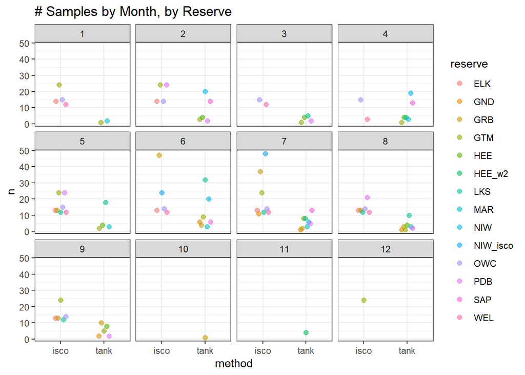

```r
dat %>%
    group_by(reserve, month, method) %>%
    summarize(n = n()) %>%
    ggplot(aes(x = method, y = n, col = reserve)) +
    geom_point(size = 2, alpha = 0.6, position = position_dodge2(width = 0.3)) +
    facet_wrap(~month, ncol = 4) +
    labs(title = "# Samples by Month, by Reserve") +
    theme_bw()
```

### Reserve by Season

```r
table(dat$reserve, dat$season)
```

```
##
##            Winter Spring Summer Fall
##   ELK          28     13     39   13
##   GND           0      0     19    2
##   GRB           0     13    106   24
##   GTM          76     28     42   29
##   HEE           4     12      4    8
##   HEE_w2        0      0      0    4
##   LKS           0     39     74   12
##   MAR           2      6      9    0
##   NIW          20     19     26    0
##   NIW_isco      0      0     72    0
##   OWC          29     45     42   14
##   PDB          26     26     28    2
##   SAP          14     13     19    0
##   WEL          12     27     36    0
```

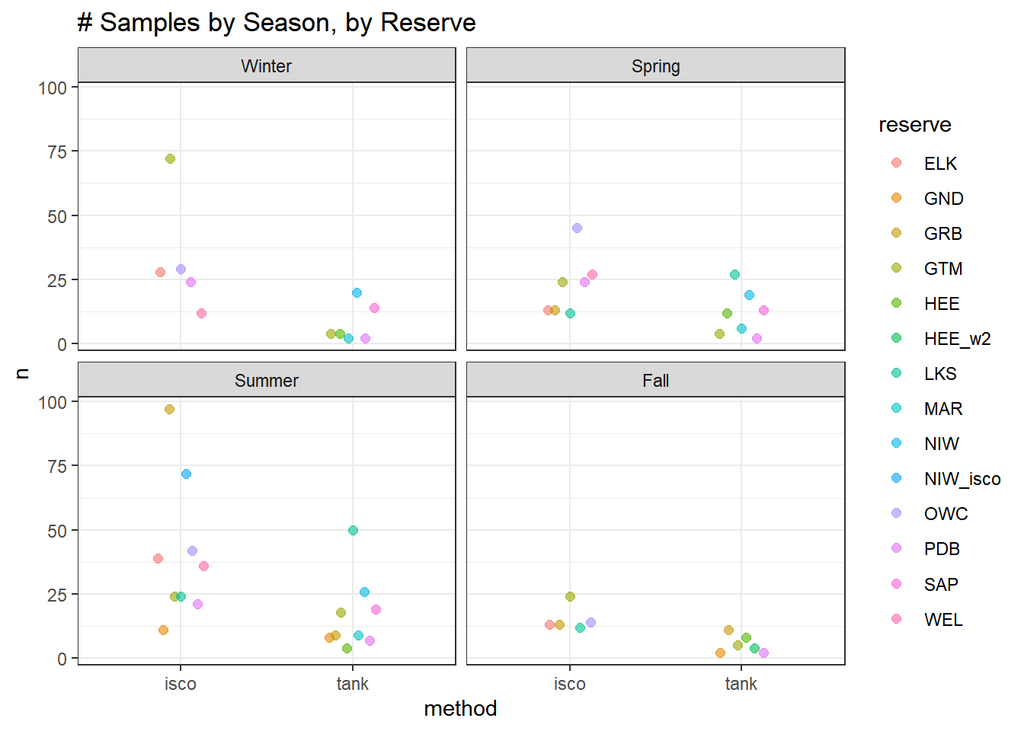

```r
dat %>%
    group_by(reserve, season, method) %>%
    summarize(n = n()) %>%
    ggplot(aes(x = method, y = n, col = reserve)) +
    geom_point(size = 2, alpha = 0.6, position = position_dodge2(width = 0.3)) +
    facet_wrap(~season, ncol = 2) +
    labs(title = "# Samples by Season, by Reserve") +
    theme_bw()
```

Values by season and reserve…..

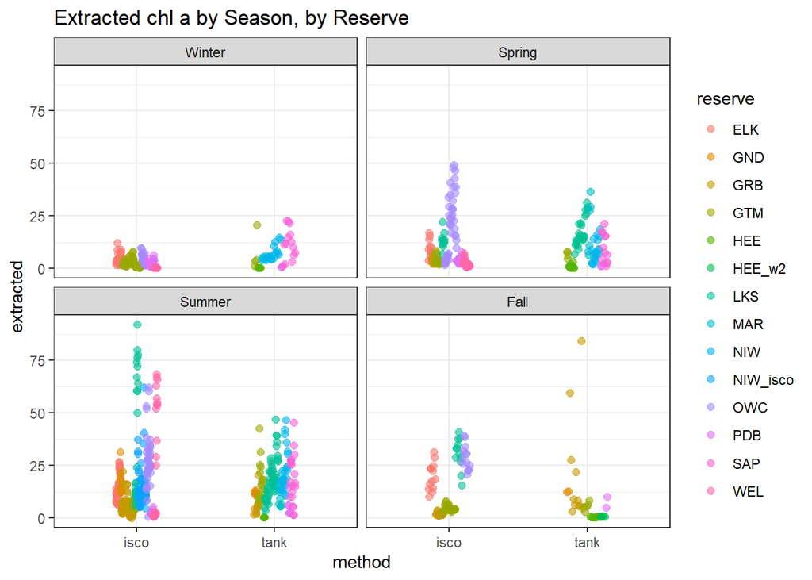

```r
dat %>%
    group_by(reserve, season, method) %>%
    ggplot(aes(x = method, y = extracted, col = reserve)) +
    geom_point(size = 2, alpha = 0.6, position = position_dodge2(width = 0.3)) +
    facet_wrap(~season, ncol = 2) +
    labs(title = "Extracted chl a by Season, by Reserve") +
    theme_bw()
```

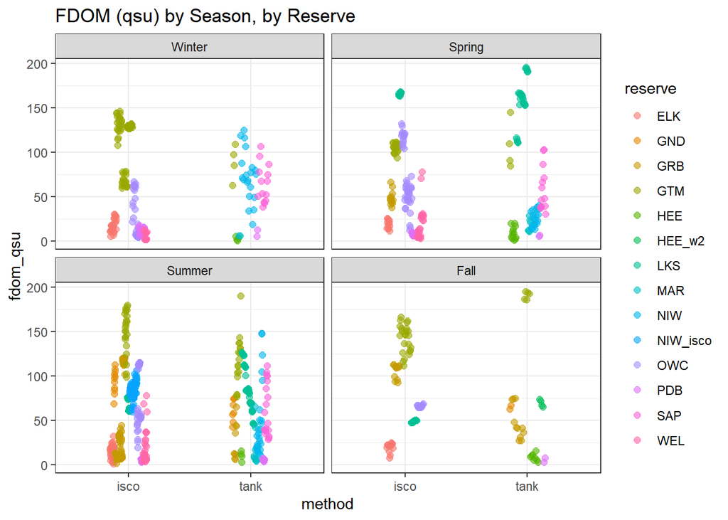

```r
dat %>%
    group_by(reserve, season, method) %>%
    ggplot(aes(x = method, y = fdom_qsu, col = reserve)) +
    geom_point(size = 2, alpha = 0.6, position = position_dodge2(width = 0.3)) +
    facet_wrap(~season, ncol = 2) +
    labs(title = "FDOM (qsu) by Season, by Reserve") +
    theme_bw()
```

### Correlations between predictors?

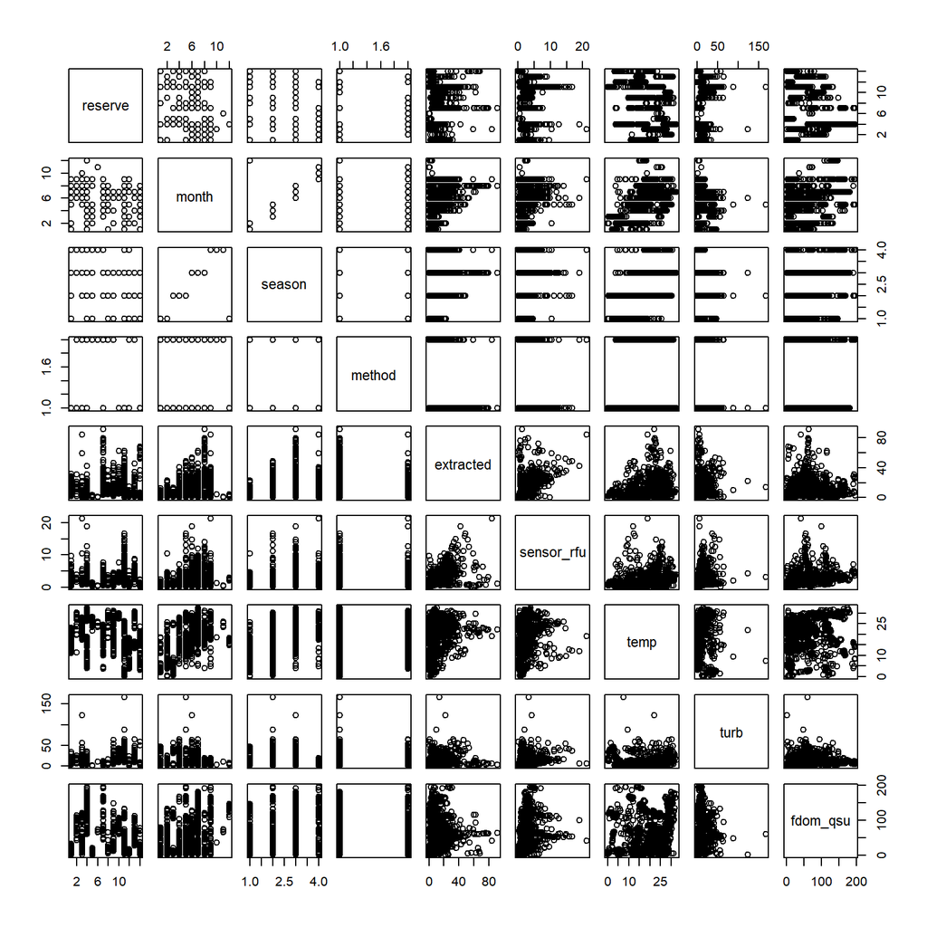

```r
dat %>%
    select(reserve, month, season, method, extracted, sensor_rfu, temp, turb, fdom_qsu) %>%
    plot()
```

# Exploring Possible Transformations of Response

Fitting a linear model with all possible predictors, then evaluating residuals and predictive performance in a rough way to see which transformation works best. This exploration led to the decision to use a square-root transformation and all following model selection will be based on square-root transformation of the response variable (extracted chlorophyll).

```r
# library(readxl)
# library(dplyr)
# library(tidyr)
# library(ggplot2)
# library(patchwork)
#
load(here::here("data", "subset_no_NA.RData"))

# original plot settings, for later
op <- par()
```

## Full Model with all interactions

response ~ sensor_rfu + turb + fdom_qsu + sensor_rfu*turb*fdom_qsu + sensor_rfu*turb + sensor_rfu*fdom_qsu + turb*fdom_qsu + temp + month + reserve

### No transformation of response

#### Fit Model

```r
full <- lm(extracted ~ sensor_rfu + turb + fdom_qsu + sensor_rfu*turb*fdom_qsu + sensor_rfu*turb + sensor_rfu*fdom_qsu + turb*fdom_qsu + temp + month + reserve, data = dat)

# diagnostics
df_untransf <- broom::glance(full)
```

#### Plot residuals

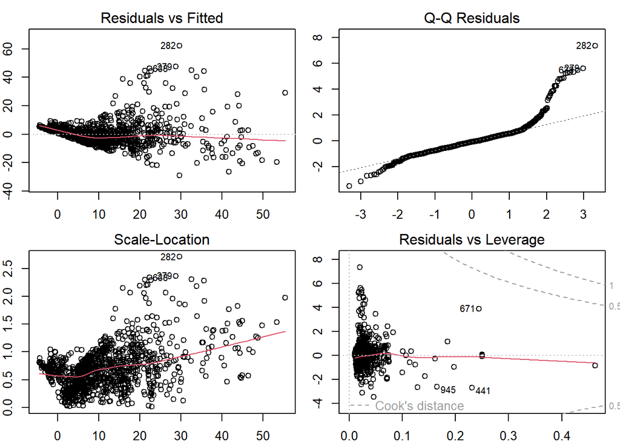

```r
par(mfrow = c(2, 2),
    mar = c(2, 2, 2, 1))
plot(full)
```

### Square-root transformation of response

#### Fit Model

```r
full_sqrt <- lm(sqrt(extracted) ~ sensor_rfu + turb + fdom_qsu + sensor_rfu*turb*fdom_qsu + sensor_rfu*turb + sensor_rfu*fdom_qsu + turb*fdom_qsu + temp + month + reserve, data = dat)

# diagnostics
df_sqrt <- broom::glance(full_sqrt)
```

#### Plot residuals

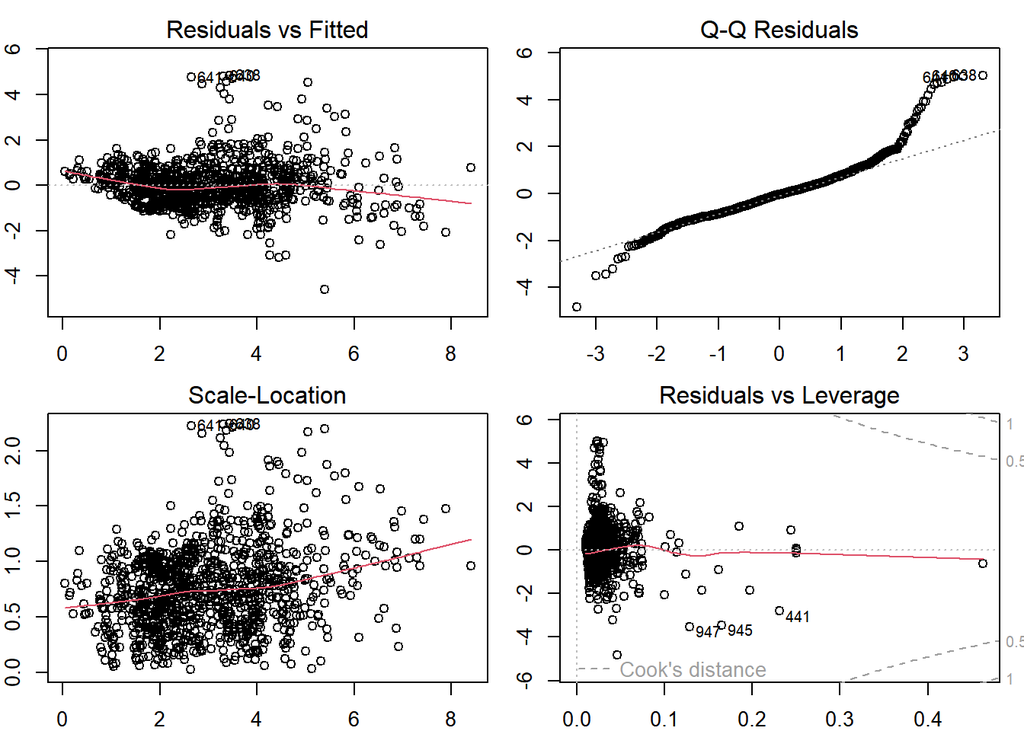

```r
par(mfrow = c(2, 2),
    mar = c(2, 2, 2, 1))
plot(full_sqrt)
```

### Fourth-root transformation of response

Similar to a natural-log transformation, but log(0) doesn’t exist so I’d like to avoid that transformation.

#### Fit Model

```r
full_frthrt <- lm(extracted^0.25 ~ sensor_rfu + turb + fdom_qsu + sensor_rfu*turb*fdom_qsu + sensor_rfu*turb + sensor_rfu*fdom_qsu + turb*fdom_qsu + temp + month + reserve, data = dat)

# diagnostics
df_frthrt <- broom::glance(full_frthrt)
```

#### Plot residuals

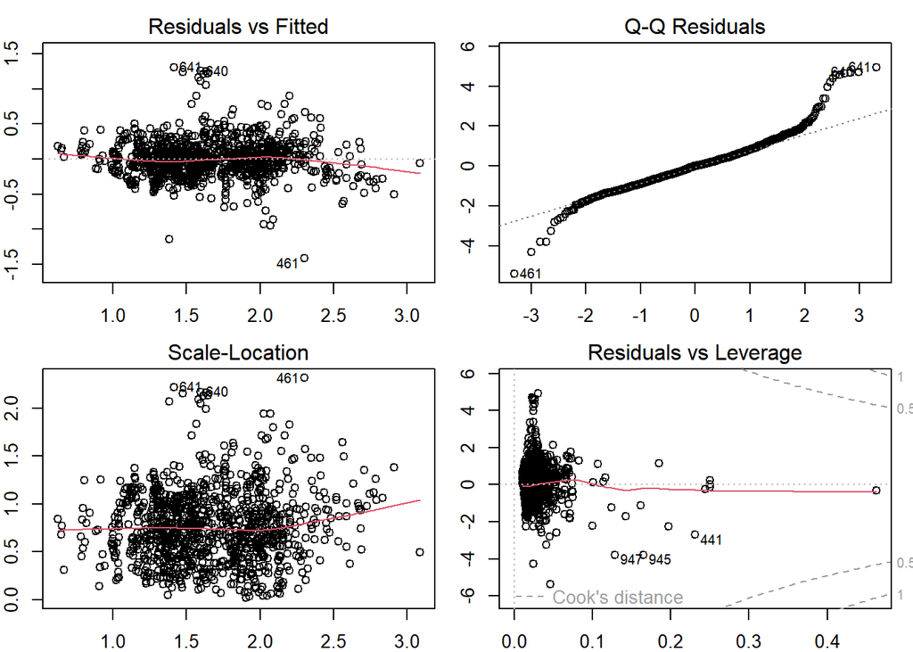

```r
par(mfrow = c(2, 2),
    mar = c(2, 2, 2, 1))
plot(full_frthrt)
```

### Log transformation of response

Because this is common and I got asked about it in a Data Team meeting.

#### Fit Model

```r
full_log10 <- lm(log10(extracted + 0.1) ~ sensor_rfu + turb + fdom_qsu + sensor_rfu*turb*fdom_qsu + sensor_rfu*turb + sensor_rfu*fdom_qsu + turb*fdom_qsu + temp + month + reserve, data = dat)

# diagnostics
df_log10 <- broom::glance(full_log10)
```

#### Plot residuals

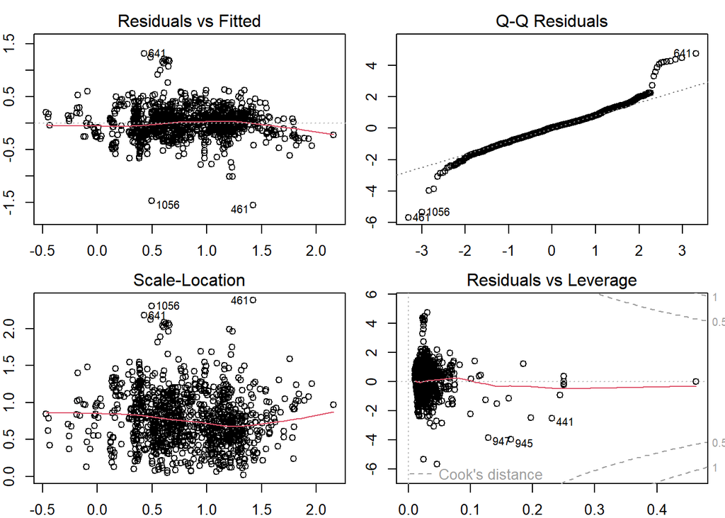

```r
par(mfrow = c(2, 2),
    mar = c(2, 2, 2, 1))
plot(full_log10)
```

## Diagnostics and predictions for all

Predictions use exponents to get them back on the original scale.

```r
dat_preds <- dat %>%
    mutate(preds_full_untr = fitted.values(full),
           preds_full_sqrt = (fitted.values(full_sqrt))^2,
           preds_full_frthrt = (fitted.values(full_frthrt))^4,
           preds_full_log10 = 10^(fitted.values(full_log10)),

           abs_dev_untr = abs(preds_full_untr - extracted),
           abs_dev_sqrt = abs(preds_full_sqrt - extracted),
           abs_dev_frthrt = abs(preds_full_frthrt - extracted),
           abs_dev_log10 = abs(preds_full_log10 - extracted))

fits <- tribble(
    ~"transformation", ~"R2", ~"AdjR2", ~"MedAbsDev",
    "none", df_untransf$r.squared, df_untransf$adj.r.squared, median(dat_preds$abs_dev_untr),
    "square-root", df_sqrt$r.squared, df_sqrt$adj.r.squared, median(dat_preds$abs_dev_sqrt),
    "fourth-root", df_frthrt$r.squared, df_frthrt$adj.r.squared, median(dat_preds$abs_dev_frthrt),
    "log10(x+0.1)", df_log10$r.squared, df_log10$adj.r.squared,
    median(dat_preds$abs_dev_log10)
)
```

### Diagnostics summary

```r
knitr::kable(fits, caption = "Diagnostics for model fit", digits = 3)
```

Diagnostics for model fit

| transformation | R2 | AdjR2 | MedAbsDev |
| --- | --- | --- | --- |
| none | 0.582 | 0.570 | 3.851 |
| square-root | 0.665 | 0.655 | 2.543 |
| fourth-root | 0.685 | 0.676 | 2.181 |
| log10(x+0.1) | 0.690 | 0.681 | 1.970 |

### Observed vs. Predicted Plots

Units are all ug/L.

The black line on the graph is the 1:1 line: we want points to be close to this line.

```r
p1 <- ggplot(dat_preds, aes(x = preds_full_untr, y = extracted, color = reserve)) +
    geom_point(size = 2, alpha = 0.4) +
    geom_abline(slope = 1, intercept = 0) +
    theme_bw() +
    labs(title = "Untransformed Model: Observed vs. Predicted Chlorophyll a",
         x = "Predicted",
         y = "Extracted")

p2 <- ggplot(dat_preds, aes(x = preds_full_sqrt, y = extracted, color = reserve)) +
    geom_point(size = 2, alpha = 0.4) +
    geom_abline(slope = 1, intercept = 0) +
    theme_bw() +
    labs(title = "Square-root transformation: Observed vs. Predicted Chlorophyll a",
         x = "Predicted",
         y = "Extracted")

p3 <- ggplot(dat_preds, aes(x = preds_full_frthrt, y = extracted, color = reserve)) +
    geom_point(size = 2, alpha = 0.4) +
    geom_abline(slope = 1, intercept = 0) +
    theme_bw() +
    labs(title = "Fourth-root transformation: Observed vs. Predicted Chlorophyll a",
         x = "Predicted",
         y = "Extracted")

p4 <- ggplot(dat_preds, aes(x = preds_full_log10, y = extracted, color = reserve)) +
    geom_point(size = 2, alpha = 0.4) +
    geom_abline(slope = 1, intercept = 0) +
    theme_bw() +
    labs(title = "Log10 transformation: Observed vs. Predicted Chlorophyll a",
         x = "Predicted",
         y = "Extracted")
```

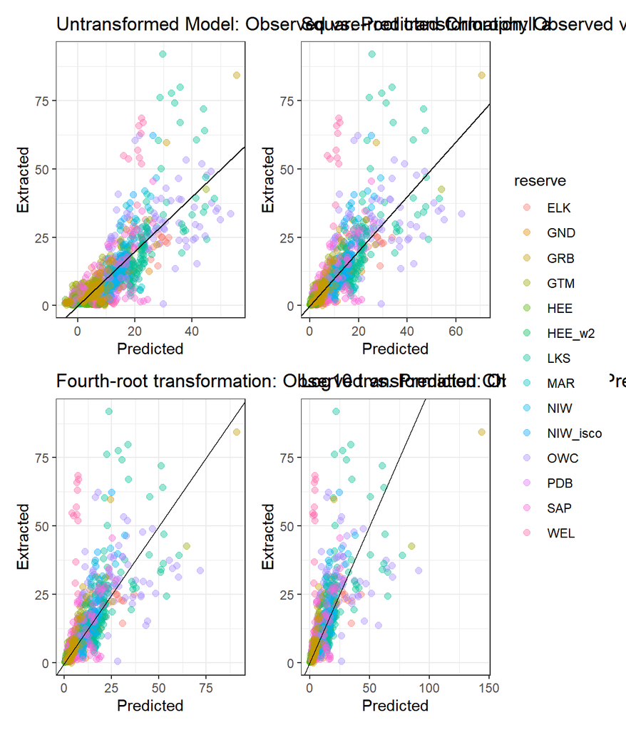

```r
(p1 + p2) / (p3 + p4) + plot_layout(guides = "collect")
```

Square-root transformation seems to do the best walking-the-line to get:

- no negative predictions for extracted chlorophyll
- generally okay linear fit without extreme prediction outliers or harsh transformation

Initial data and model exploration (not shown in this document; see instead the older `01_first_models_and_transformations` files) suggested that distinguishing between ISCO and tank samples at a site did not improve the model (no better AIC than lumping). However, due to huge anecdotal differences at two reserves (GTM and LKS) and the potential for differences at other reserves, models will be run both ways: with all data (Tank + ISCO), and with tank-only data.

# Models + Graphics: All Reserves Combined; Tank + ISCO

```r
load(here::here("data", "subset_no_NA.RData"))
# dat <- filter(dat, method == "tank")

# original plot settings, for later
op <- par()

# options, for MuMIn operations
# will prevent fitting sub-models to different datasets (from help file)
options(na.action = "na.fail")
```

```r
# create "response" column
dat$response <- sqrt(dat$extracted)
```

## Modeling: All Reserves, Tank + ISCO

At one point, I coded LMMs. But they are very data-hungry and based on `05_model_selection_combined_reserves`, didn’t seem to make very different predictions. In theory they are better for various reasons but we are proceeding with only Ordinary Least Squares (OLS) models here.

Each of the models described below are fitted and evaluated using symmetric Median Absolute Percent Error.

**n** (number of points in the dataset): 1076

from 14 reserves

**Full Model**

Includes all interactions between sensor_rfu, turbidity, and FDOM. Additionally, temp*rfu and temp*fdom. Hoping we can actually drop some of these.

Reserve included as fixed effect.

response ~ sensor_rfu + turb + fdom_qsu + sensor_rfu*turb*fdom_qsu + sensor_rfu*turb + sensor_rfu*fdom_qsu + turb*fdom_qsu + temp + sensor_rfu*temp + fdom_qsu*temp + season + reserve

**No FDOM**

If we drop FDOM and all its interactions, what do we get?

**NOTE** this still includes both reserve and season (as well as sensor readings from temp and turbidity)

**RFU only**

This does *not* include reserve or season. If the other models above are better, reserve or season could still be the reason (vs. turbidity/temp/FDOM corrections). It would mean **local factors still have to be accounted for and modelled to get the most out of a TAL sensor**.

```r
# Changed coding to be more similar to the individual reserve files; re-ran using all NIW data lumped together (and all HEE data lumped together) - got same coefficients as before. Individual reserve files use leave-one-out cross-validation, but here I'm using 10-fold because otherwise it's a lot.

set.seed(1216)
full_ols <- glm(response ~ sensor_rfu + turb + fdom_qsu + sensor_rfu*turb*fdom_qsu + sensor_rfu*turb + sensor_rfu*fdom_qsu + turb*fdom_qsu + temp + sensor_rfu*temp + fdom_qsu*temp + season + reserve, data = dat)

no_fdom_ols <- glm(response ~ sensor_rfu + turb +  sensor_rfu*turb + temp + sensor_rfu*temp + season + reserve, data = dat)

no_fdom_lm <- lm(response ~ sensor_rfu + turb +  sensor_rfu*turb + temp + sensor_rfu*temp + season + reserve, data = dat)


rfu_only <- glm(response ~ sensor_rfu, data = dat)
rfu_only_lm <- lm(response ~ sensor_rfu, data = dat)

sel <- dredge(full_ols,
              fixed = "sensor_rfu",
              extra = c("R^2", "AdjR^2" = function(x) summary(x)$adj.r.squared))

# perform 10-fold cross-validation on top model to find median prediction error
# cost function is sMdAPE; defined in parent Rmd
ols.1 <- get.models(sel, 1)[[1]]
ols.cv <- cv.glm(dat, ols.1, cost, K = 10)

no_fdom.cv <- cv.glm(dat, no_fdom_ols, cost, K = 10)
no_fdom.df <- data.frame(model.sel(no_fdom_ols))
no_fdom.df$pred_test_error <- round(no_fdom.cv$delta[1], 2)

rfu_only.cv <- cv.glm(dat, rfu_only, cost, K = 10)
rfu_only.df <- data.frame(model.sel(rfu_only))
rfu_only.df$pred_test_error <- round(rfu_only.cv$delta[1], 2)

# pull out R^2s from lms (glms were run for cross-validation but really they're just regular linear models)
no_fdom.df$R.2 <- round(summary(no_fdom_lm)$r.squared, 4)
rfu_only.df$R.2 <- round(summary(rfu_only_lm)$r.squared, 4)


# only top one
subdf <- data.frame(sel[1])
subdf$pred_test_error <- round(ols.cv$delta[1], 2)
subdf <- subdf %>%
  bind_rows(no_fdom.df, rfu_only.df) %>%
  tibble::rownames_to_column(var = "model") %>%
  mutate(model = case_when(model == "...1" ~ "best_AIC",
                           TRUE ~ model)) %>%
  select(model, AICc, R.2, pred_test_error, everything()) %>%
  select(-c(delta, weight))
```

## Summary Table for main models

```r
coeffs <- subdf %>%
    select(reserve, model, AICc, R.2, prediction_error = pred_test_error,
           sensor_rfu, fdom_qsu, turb, temp, season,
           everything()) %>%
    mutate(across(c(AICc, prediction_error), round, 2),
           across(c(R.2, sensor_rfu, X.Intercept.), round, 3),
           across(c(fdom_qsu, turb, temp), round, 4),
           across(c(fdom_qsu.sensor_rfu:fdom_qsu.sensor_rfu.turb), round, 4) )

knitr::kable(coeffs)
```

| reserve | model | AICc | R.2 | prediction_error | sensor_rfu | fdom_qsu | turb | temp | season | X.Intercept. | fdom_qsu.sensor_rfu | fdom_qsu.temp | fdom_qsu.turb | sensor_rfu.temp | sensor_rfu.turb | fdom_qsu.sensor_rfu.turb | df | logLik |
| --- | --- | --- | --- | --- | --- | --- | --- | --- | --- | --- | --- | --- | --- | --- | --- | --- | --- | --- |
| + | best_AIC | 3047.98 | 0.656 | 36.15 | 0.557 | 6e-04 | 0.0253 | 0.1248 | + | 0.170 | NA | -4e-04 | NA | -0.0117 | -0.0038 | NA | 25 | -1498.370 |
| + | no_fdom_ols | 3115.80 | 0.633 | 37.87 | 0.608 | NA | 0.0251 | 0.0915 | + | 0.569 | NA | NA | NA | -0.0143 | -0.0039 | NA | 23 | -1534.378 |
| NA | rfu_only | 3768.92 | 0.300 | 56.36 | 0.375 | NA | NA | NA | NA | 2.013 | NA | NA | NA | NA | NA | NA | 3 | -1881.447 |

```r
# save out to CSV
write.csv(coeffs, file = here::here("model_coeffs",                                     "AllRes_TankAndISCO.csv"), row.names = FALSE)
```

## Graphics

```r
dat2 <- dat %>%
    mutate(preds_ols = (predict(ols.1, newdata = dat))^2,
           preds_nofdom_ols = (predict(no_fdom_ols, newdata = dat))^2,
           preds_rfu = (predict(rfu_only, newdata = dat))^2)%>%
    arrange(extracted) %>%
    mutate(rownum = row_number())

# save out to csv
write.csv(dat2, file = here::here("model_predictions", "AllRes_TankAndISCO_preds.csv"), row.names = FALSE)
```

```r
dat2_long <- dat2 %>%
  select(reserve, month, season, method, extracted, starts_with("preds")) %>%
  pivot_longer(cols = starts_with("preds"),
               names_to = "model",
               names_prefix = "preds_",
               values_to = "predicted")
```

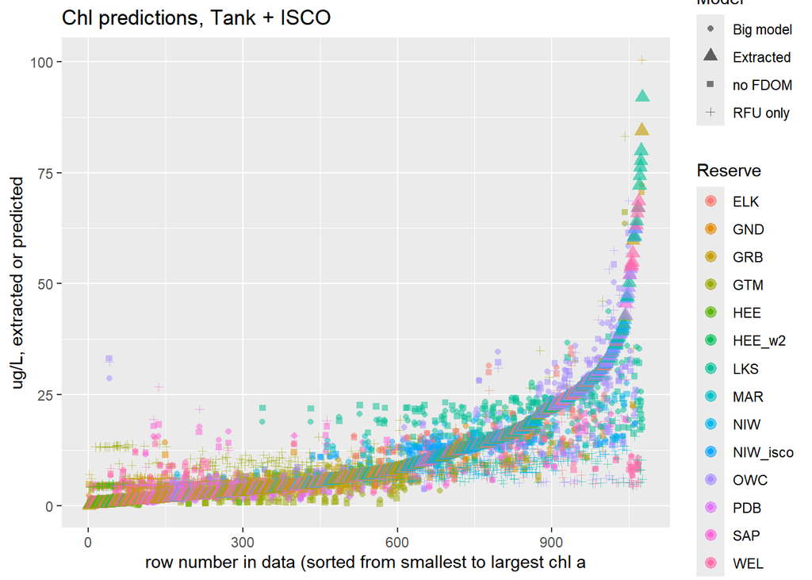

```r
ggplot(dat2, aes(x = rownum)) +
  geom_point(aes(y = preds_ols, shape = "Big model", color = reserve), alpha = 0.5) +
  geom_point(aes(y = preds_nofdom_ols, shape = "no FDOM", color = reserve), alpha = 0.5) +
  geom_point(aes(y = preds_rfu, shape = "RFU only", color = reserve), alpha = 0.5) +
  geom_point(aes(y = extracted, shape = "Extracted", color = reserve), size = 3, alpha = 0.6) +
  labs(title = "Chl predictions, Tank + ISCO",
       x = "row number in data (sorted from smallest to largest chl a",
       y = "ug/L, extracted or predicted",
       color = "Reserve",
       shape = "Model")
```

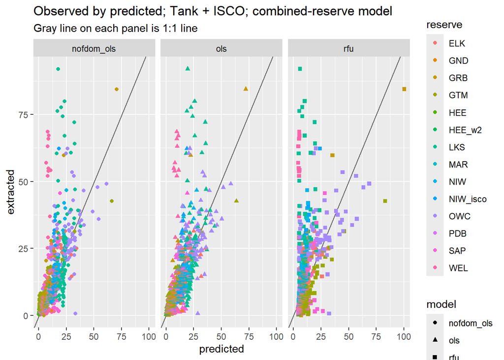

```r
ggplot(dat2_long) +
  geom_abline(slope = 1, intercept = 0, color = "gray40") +
  geom_point(aes(x = predicted, y = extracted, color = reserve, shape = model)) +
  facet_wrap(~model) +
  labs(title = "Observed by predicted; Tank + ISCO; combined-reserve model",
       subtitle = "Gray line on each panel is 1:1 line")
```

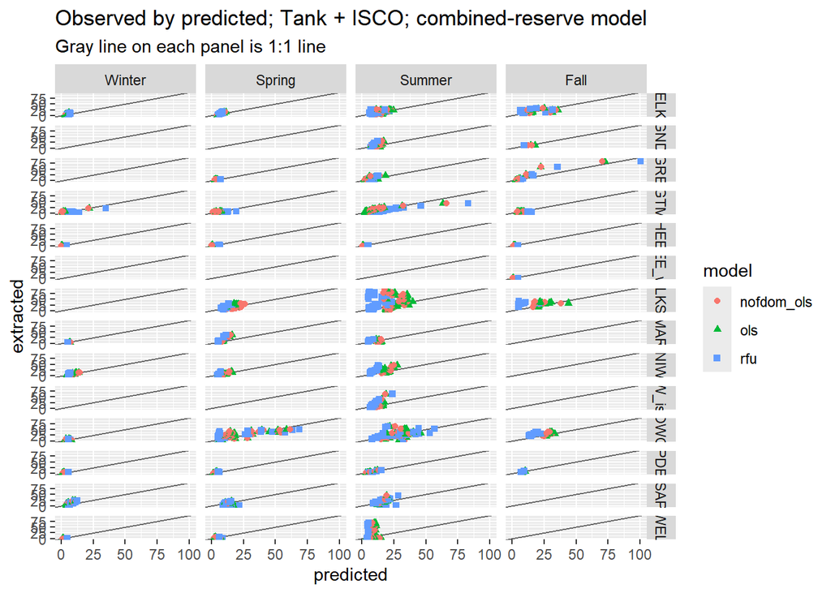

```r
ggplot(dat2_long) +
  geom_abline(slope = 1, intercept = 0, color = "gray40") +
  geom_point(aes(x = predicted, y = extracted, color = model, shape = model)) +
  facet_grid(reserve ~ season) +
  labs(title = "Observed by predicted; Tank + ISCO; combined-reserve model",
       subtitle = "Gray line on each panel is 1:1 line")
```

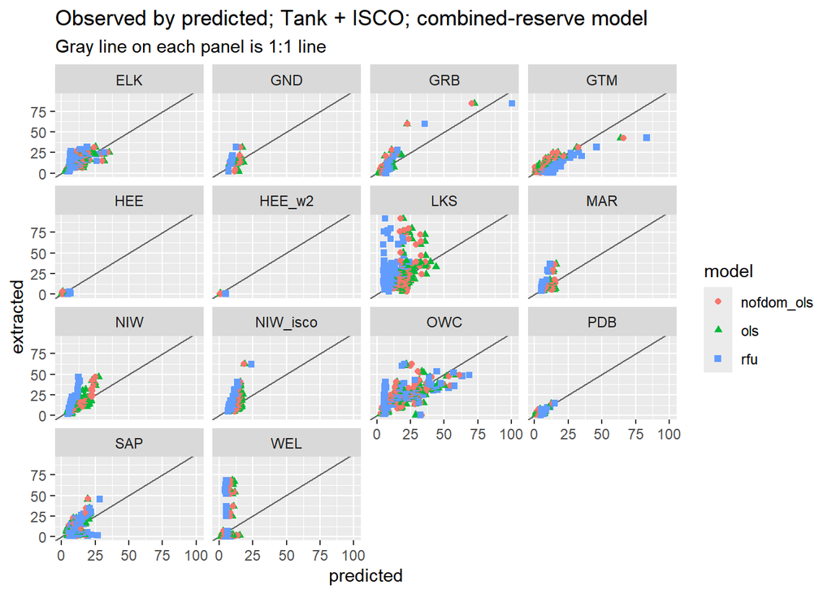

```r
ggplot(dat2_long) +
  geom_abline(slope = 1, intercept = 0, color = "gray40") +
  geom_point(aes(x = predicted, y = extracted, color = model, shape = model)) +
  facet_wrap(~reserve) +
  labs(title = "Observed by predicted; Tank + ISCO; combined-reserve model",
       subtitle = "Gray line on each panel is 1:1 line")
```

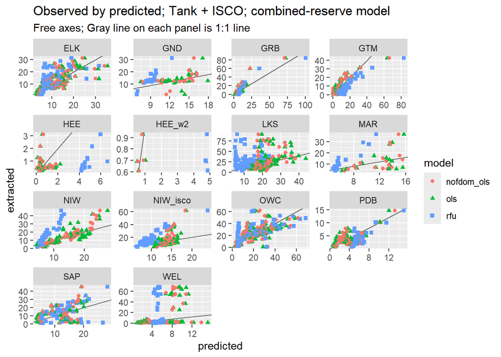

```r
ggplot(dat2_long) +
  geom_abline(slope = 1, intercept = 0, color = "gray40") +
  geom_point(aes(x = predicted, y = extracted, color = model, shape = model)) +
  facet_wrap(~reserve, scales = "free") +
  labs(title = "Observed by predicted; Tank + ISCO; combined-reserve model",
       subtitle = "Free axes; Gray line on each panel is 1:1 line")
```

# Models + Graphics: All Reserves Combined; Tank Only

```r
load(here::here("data", "subset_no_NA.RData"))
dat <- filter(dat, method == "tank")

# original plot settings, for later
op <- par()

# options, for MuMIn operations
# will prevent fitting sub-models to different datasets (from help file)
options(na.action = "na.fail")
```

```r
# create "response" column
dat$response <- sqrt(dat$extracted)
```

## Modeling: All Reserves, Tank Only

At one point, I coded LMMs. But they are very data-hungry and based on `05_model_selection_combined_reserves`, didn’t seem to make very different predictions. In theory they are better for various reasons but we are proceeding with only Ordinary Least Squares (OLS) models here.

Each of the models described below are fitted and evaluated using symmetric Median Absolute Percent Error.

**n** (number of points in the dataset): 311

from 10 reserves

**Full Model**

Includes all interactions between sensor_rfu, turbidity, and FDOM. Additionally, temp*rfu and temp*fdom. Hoping we can actually drop some of these.

Reserve included as fixed effect.

response ~ sensor_rfu + turb + fdom_qsu + sensor_rfu*turb*fdom_qsu + sensor_rfu*turb + sensor_rfu*fdom_qsu + turb*fdom_qsu + temp + sensor_rfu*temp + fdom_qsu*temp + season + reserve

**No FDOM**

If we drop FDOM and all its interactions, what do we get?

**NOTE** this still includes both reserve and season (as well as sensor readings from temp and turbidity)

**RFU only**

This does *not* include reserve or season. If the other models above are better, reserve or season could still be the reason (vs. turbidity/temp/FDOM corrections). It would mean **local factors still have to be accounted for and modeled to get the most out of a TAL sensor**.

**RFU + season**

**Temp-Corrected RFU + season**

Temp-corrected RFU is denoted as `tc_rfu` in the model names and objects. The correction was based on a global rho value which was the average of all individual rho values, as calculated by Hannah Ramage, from the temperature interference trials. This global rho value was then inserted into the equation from Watras et al. 2017 as follows:

Temp-corrected-RFU = original-RFU / (1 + global_rho*(temp_reading - 20))

```r
# Changed coding to be more similar to the individual reserve files; re-ran using all NIW data lumped together (and all HEE data lumped together) - got same coefficients as before. Individual reserve files use leave-one-out cross-validation, but here I'm using 10-fold because otherwise it's a lot.

# 2/16/22 adding some new models of interest, and really wishing I'd somehow made everything below into a function. Still not sure how, but it would have helped a lot.

set.seed(1216)
full_ols <- glm(response ~ sensor_rfu + turb + fdom_qsu + sensor_rfu*turb*fdom_qsu + sensor_rfu*turb + sensor_rfu*fdom_qsu + turb*fdom_qsu + temp + sensor_rfu*temp + fdom_qsu*temp + season + reserve, data = dat)

no_fdom_ols <- glm(response ~ sensor_rfu + turb +  sensor_rfu*turb + temp + sensor_rfu*temp + season + reserve, data = dat)

no_fdom_lm <- lm(response ~ sensor_rfu + turb +  sensor_rfu*turb + temp + sensor_rfu*temp + season + reserve, data = dat)

rfu_only <- glm(response ~ sensor_rfu, data = dat)
rfu_only_lm <- lm(response ~ sensor_rfu, data = dat)

rfu_season <- glm(response ~ sensor_rfu + season, data = dat)
rfu_season_lm <- lm(response ~ sensor_rfu + season, data = dat)

rfu_reserve <- glm(response ~ sensor_rfu + reserve, data = dat)
rfu_reserve_lm <- lm(response ~ sensor_rfu + reserve, data = dat)

rfu_season_res <- glm(response ~ sensor_rfu + season + reserve, data = dat)
rfu_season_res_lm <- lm(response ~ sensor_rfu + season + reserve, data = dat)

tc_rfu_season <- glm(response ~ rfu_temp_corrected + season, data = dat)
tc_rfu_season_lm <- lm(response ~ rfu_temp_corrected + season, data = dat)

tc_rfu_reserve <- glm(response ~ rfu_temp_corrected + reserve, data = dat)
tc_rfu_reserve_lm <- lm(response ~ rfu_temp_corrected + reserve, data = dat)

tc_rfu_season_res <- glm(response ~ rfu_temp_corrected + season + reserve, data = dat)
tc_rfu_season_res_lm <- lm(response ~ rfu_temp_corrected + season + reserve, data = dat)

sel <- dredge(full_ols,
              fixed = "sensor_rfu",
              extra = c("R^2", "AdjR^2" = function(x) summary(x)$adj.r.squared))

# perform 10-fold cross-validation on top model to find median prediction error
# cost function is sMdAPE; defined in parent Rmd
ols.1 <- get.models(sel, 1)[[1]]
ols.cv <- cv.glm(dat, ols.1, cost, K = 10)

no_fdom.cv <- cv.glm(dat, no_fdom_ols, cost, K = 10)
no_fdom.df <- data.frame(model.sel(no_fdom_ols))
no_fdom.df$pred_test_error <- round(no_fdom.cv$delta[1], 2)

rfu_only.cv <- cv.glm(dat, rfu_only, cost, K = 10)
rfu_only.df <- data.frame(model.sel(rfu_only))
rfu_only.df$pred_test_error <- round(rfu_only.cv$delta[1], 2)

rfu_season.cv <- cv.glm(dat, rfu_season, cost, K = 10)
rfu_season.df <- data.frame(model.sel(rfu_season))
rfu_season.df$pred_test_error <- round(rfu_season.cv$delta[1], 2)

rfu_reserve.cv <- cv.glm(dat, rfu_reserve, cost, K = 10)
rfu_reserve.df <- data.frame(model.sel(rfu_reserve))
rfu_reserve.df$pred_test_error <- round(rfu_reserve.cv$delta[1], 2)

rfu_season_res.cv <- cv.glm(dat, rfu_season_res, cost, K = 10)
rfu_season_res.df <- data.frame(model.sel(rfu_season_res))
rfu_season_res.df$pred_test_error <- round(rfu_season_res.cv$delta[1], 2)

tc_rfu_season.cv <- cv.glm(dat, tc_rfu_season, cost, K = 10)
tc_rfu_season.df <- data.frame(model.sel(tc_rfu_season))
tc_rfu_season.df$pred_test_error <- round(tc_rfu_season.cv$delta[1], 2)

tc_rfu_reserve.cv <- cv.glm(dat, tc_rfu_reserve, cost, K = 10)
tc_rfu_reserve.df <- data.frame(model.sel(tc_rfu_reserve))
tc_rfu_reserve.df$pred_test_error <- round(tc_rfu_reserve.cv$delta[1], 2)

tc_rfu_season_res.cv <- cv.glm(dat, tc_rfu_season_res, cost, K = 10)
tc_rfu_season_res.df <- data.frame(model.sel(tc_rfu_season_res))
tc_rfu_season_res.df$pred_test_error <- round(tc_rfu_season_res.cv$delta[1], 2)


# pull out R^2s from lms (glms were run for cross-validation but really they're just regular linear models)
no_fdom.df$R.2 <- round(summary(no_fdom_lm)$r.squared, 4)
rfu_only.df$R.2 <- round(summary(rfu_only_lm)$r.squared, 4)
rfu_season.df$R.2 <- round(summary(rfu_season_lm)$r.squared, 4)
rfu_reserve.df$R.2 <- round(summary(rfu_reserve_lm)$r.squared, 4)
rfu_season_res.df$R.2 <- round(summary(rfu_season_res_lm)$r.squared, 4)
tc_rfu_season.df$R.2 <- round(summary(tc_rfu_season_lm)$r.squared, 4)
tc_rfu_reserve.df$R.2 <- round(summary(tc_rfu_reserve_lm)$r.squared, 4)
tc_rfu_season_res.df$R.2 <- round(summary(tc_rfu_season_res_lm)$r.squared, 4)

# only top one
subdf <- data.frame(sel[1])
subdf$pred_test_error <- round(ols.cv$delta[1], 2)
subdf <- subdf %>%
  bind_rows(no_fdom.df, rfu_only.df,
            rfu_season.df, rfu_reserve.df, rfu_season_res.df,
            tc_rfu_season.df, tc_rfu_reserve.df, tc_rfu_season_res.df) %>%
  tibble::rownames_to_column(var = "model") %>%
  mutate(model = case_when(model == "...1" ~ "best_AIC",
                           TRUE ~ model)) %>%
  select(model, AICc, R.2, pred_test_error,
         sensor_rfu, rfu_temp_corrected, everything()) %>%
  select(-c(delta, weight))
```

## Summary Table for main models

```r
coeffs <- subdf %>%
    select(reserve, model, AICc, R.2, prediction_error = pred_test_error,
           sensor_rfu, rfu_temp_corrected, fdom_qsu, turb, temp, season,
           everything()) %>%
    mutate(across(c(AICc, prediction_error), round, 2),
           across(c(R.2, sensor_rfu, rfu_temp_corrected, X.Intercept.), round, 3),
           across(c(fdom_qsu, turb, temp), round, 4),
           across(c(fdom_qsu.sensor_rfu:fdom_qsu.sensor_rfu.turb), round, 4) )

knitr::kable(coeffs)
```

| reserve | model | AICc | R.2 | prediction_error | sensor_rfu | rfu_temp_corrected | fdom_qsu | turb | temp | season | X.Intercept. | fdom_qsu.sensor_rfu | fdom_qsu.temp | fdom_qsu.turb | sensor_rfu.temp | sensor_rfu.turb | fdom_qsu.sensor_rfu.turb | df | logLik |
| --- | --- | --- | --- | --- | --- | --- | --- | --- | --- | --- | --- | --- | --- | --- | --- | --- | --- | --- | --- |
| + | best_AIC | 701.99 | 0.787 | 25.91 | 0.234 | NA | 0.0032 | 0.1258 | 0.0246 | NA | 1.162 | 0.0013 | -6e-04 | NA | 0.0174 | -0.0267 | NA | 19 | -330.6868 |
| + | no_fdom_ols | 717.20 | 0.777 | 26.43 | 0.408 | NA | NA | 0.1101 | -0.0244 | + | 1.368 | NA | NA | NA | 0.0108 | -0.0242 | NA | 19 | -338.2936 |
| NA | rfu_only | 982.22 | 0.415 | 49.24 | 0.389 | NA | NA | NA | NA | NA | 2.176 | NA | NA | NA | NA | NA | NA | 3 | -488.0699 |
| NA | rfu_season | 956.37 | 0.472 | 47.81 | 0.359 | NA | NA | NA | NA | + | 1.947 | NA | NA | NA | NA | NA | NA | 6 | -472.0452 |
| + | rfu_reserve | 784.10 | 0.709 | 30.67 | 0.437 | NA | NA | NA | NA | NA | 2.106 | NA | NA | NA | NA | NA | NA | 12 | -379.5258 |
| + | rfu_season_res | 775.58 | 0.723 | 29.29 | 0.414 | NA | NA | NA | NA | + | 1.734 | NA | NA | NA | NA | NA | NA | 15 | -371.9776 |
| NA | tc_rfu_season | 944.79 | 0.492 | 46.93 | NA | 0.381 | NA | NA | NA | + | 1.957 | NA | NA | NA | NA | NA | NA | 6 | -466.2572 |
| + | tc_rfu_reserve | 777.34 | 0.715 | 28.28 | NA | 0.435 | NA | NA | NA | NA | 2.067 | NA | NA | NA | NA | NA | NA | 12 | -376.1480 |
| + | tc_rfu_season_res | 776.13 | 0.722 | 27.95 | NA | 0.416 | NA | NA | NA | + | 1.836 | NA | NA | NA | NA | NA | NA | 15 | -372.2538 |

```r
# save out to CSV
write.csv(coeffs, file = here::here("model_coeffs",                                     "AllRes_TankOnly.csv"), row.names = FALSE)
```

## Graphics

```r
dat2 <- dat %>%
    mutate(preds_ols = (predict(ols.1, newdata = dat))^2,
           preds_nofdom_ols = (predict(no_fdom_ols, newdata = dat))^2,
           preds_rfu = (predict(rfu_only, newdata = dat))^2,
           preds_rfu_season = (predict(rfu_season, newdata = dat))^2,
           preds_rfu_reserve = (predict(rfu_reserve, newdata = dat))^2,
           preds_rfu_season_res = (predict(rfu_season_res, newdata = dat))^2,
           preds_tc_rfu_season = (predict(tc_rfu_season, newdata = dat))^2,
           preds_tc_rfu_reserve = (predict(tc_rfu_reserve, newdata = dat))^2,
           preds_tc_rfu_season_res = (predict(tc_rfu_season_res, newdata = dat))^2)%>%
    arrange(extracted) %>%
    mutate(rownum = row_number())

# save out to csv
write.csv(dat2, file = here::here("model_predictions", "AllRes_TankOnly_preds.csv"), row.names = FALSE)
```

```r
dat2_long <- dat2 %>%
  select(reserve, month, season, method, extracted, starts_with("preds")) %>%
  pivot_longer(cols = starts_with("preds"),
               names_to = "model",
               names_prefix = "preds_",
               values_to = "predicted")
```

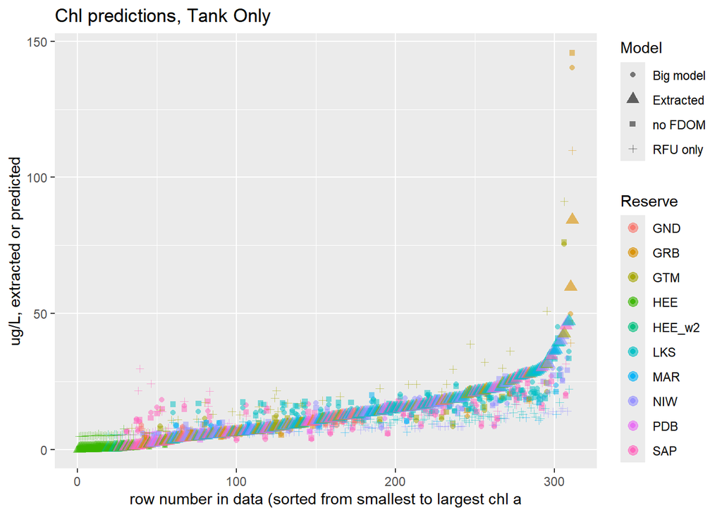

```r
ggplot(dat2, aes(x = rownum)) +
  geom_point(aes(y = preds_ols, shape = "Big model", color = reserve), alpha = 0.5) +
  geom_point(aes(y = preds_nofdom_ols, shape = "no FDOM", color = reserve), alpha = 0.5) +
  geom_point(aes(y = preds_rfu, shape = "RFU only", color = reserve), alpha = 0.5) +
  geom_point(aes(y = extracted, shape = "Extracted", color = reserve), size = 3, alpha = 0.6) +
  labs(title = "Chl predictions, Tank Only",
       x = "row number in data (sorted from smallest to largest chl a",
       y = "ug/L, extracted or predicted",
       color = "Reserve",
       shape = "Model")
```

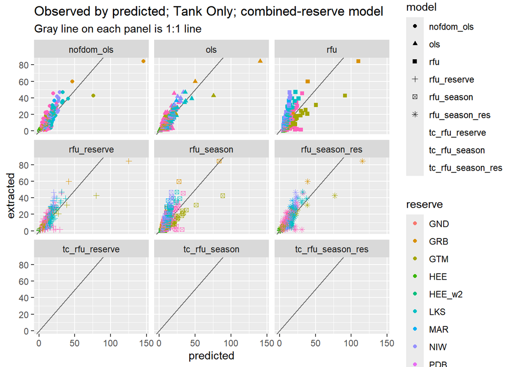

```r
ggplot(dat2_long) +
  geom_abline(slope = 1, intercept = 0, color = "gray40") +
  geom_point(aes(x = predicted, y = extracted, color = reserve, shape = model)) +
  facet_wrap(~model) +
  labs(title = "Observed by predicted; Tank Only; combined-reserve model",
       subtitle = "Gray line on each panel is 1:1 line")
```

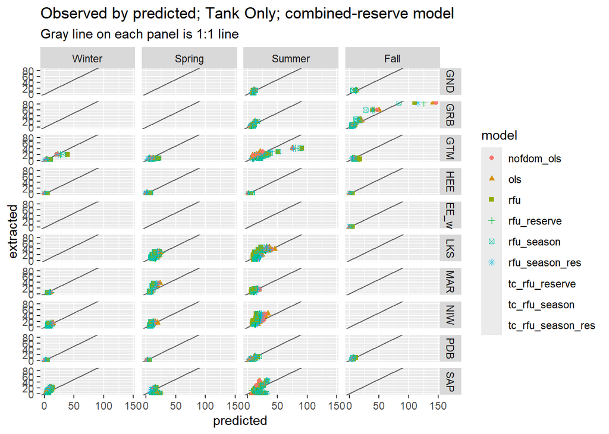

```r
ggplot(dat2_long) +
  geom_abline(slope = 1, intercept = 0, color = "gray40") +
  geom_point(aes(x = predicted, y = extracted, color = model, shape = model)) +
  facet_grid(reserve ~ season) +
  labs(title = "Observed by predicted; Tank Only; combined-reserve model",
       subtitle = "Gray line on each panel is 1:1 line")
```

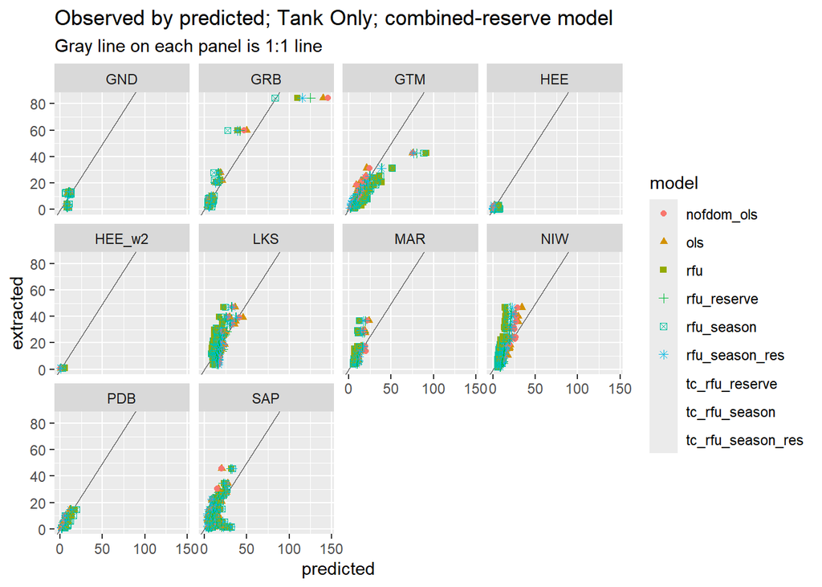

```r
ggplot(dat2_long) +
  geom_abline(slope = 1, intercept = 0, color = "gray40") +
  geom_point(aes(x = predicted, y = extracted, color = model, shape = model)) +
  facet_wrap(~reserve) +
  labs(title = "Observed by predicted; Tank Only; combined-reserve model",
       subtitle = "Gray line on each panel is 1:1 line")
```

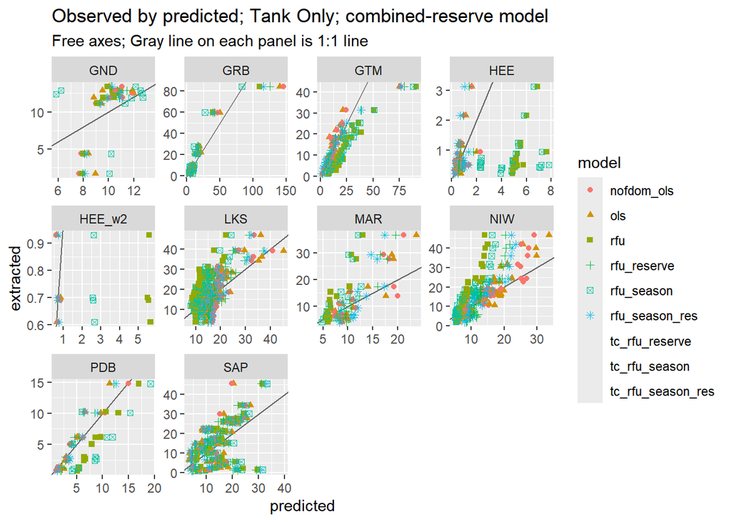

```r
ggplot(dat2_long) +
  geom_abline(slope = 1, intercept = 0, color = "gray40") +
  geom_point(aes(x = predicted, y = extracted, color = model, shape = model)) +
  facet_wrap(~reserve, scales = "free") +
  labs(title = "Observed by predicted; Tank Only; combined-reserve model",
       subtitle = "Free axes; Gray line on each panel is 1:1 line")
```

```r
diags <- coeffs %>%
  select(model, AICc, R.2, prediction_error) %>%
  pivot_longer(-model, names_to = "diagnostic", values_to = "value") %>%
  mutate(diagnostic = case_when(diagnostic == "R.2" ~ "R^2",
                                diagnostic == "prediction_error" ~ "Prediction Error",
                                TRUE ~ diagnostic),
         model_type = case_when(stringr::str_starts(model, "rfu") ~ "RFU",
                                stringr::str_starts(model, "tc_rfu") ~ "TC-RFU",
                                TRUE ~ "multi-vars"))
```

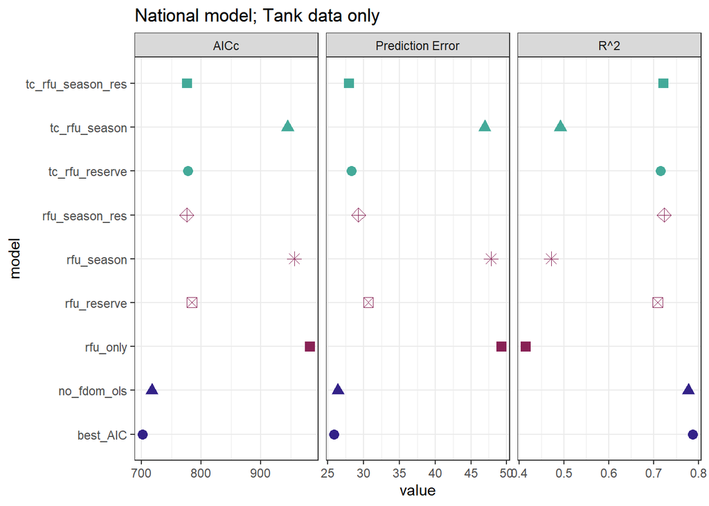

```r
# default will use max of 6 shapes. they are:
# 16, 17, 15, 3, 7, 8

my_shapes <- c(16, 17, 15, 7, 8, 9)

# colors below are from khroma::muted and are colorblind-friendly
# though that's not really necessary here because we also have shapes and names

ggplot(diags, aes(x = value, y = model)) +
  geom_point(size = 3, aes(color = model_type, shape = model)) +
  facet_wrap(~diagnostic, nrow = 1, scales = "free_x") +
  scale_shape_manual(values = rep(my_shapes, 2)) +
  scale_color_manual(values = c("#332288", "#882255", "#44AA99")) +
  theme_bw() +
  theme(legend.position = "none") +
  ggtitle("National model; Tank data only")
```

```r
ggsave(here::here("model_coeffs", "diagnostics_multimodels_national_tank.png"),
       width = 8, height = 4, units = "in")
```

You need reserve. Season helps, but primarily, you need reserve. Tweaking beyond that with temperature-correcting RFU, including turbidity and/or FDOM, etc., could improve things. But including ‘Reserve’ has the most impact on the model, repeatedly. So if you want a really good model, you have to put in some work to get the samples at your reserve.

# Models + Graphics: All Reserves Combined; ISCO Only

```r
load(here::here("data", "subset_no_NA.RData"))
dat <- filter(dat, method == "isco")

# original plot settings, for later
op <- par()

# options, for MuMIn operations
# will prevent fitting sub-models to different datasets (from help file)
options(na.action = "na.fail")
```

```r
# create "response" column
dat$response <- sqrt(dat$extracted)
```

## Modeling: All Reserves, ISCO Only

At one point, I coded LMMs. But they are very data-hungry and based on `05_model_selection_combined_reserves`, didn’t seem to make very different predictions. In theory they are better for various reasons but we are proceeding with only Ordinary Least Squares (OLS) models here.

Each of the models described below are fitted and evaluated using symmetric Median Absolute Percent Error.

**n** (number of points in the dataset): 765

from 9 reserves

**Full Model**

Includes all interactions between sensor_rfu, turbidity, and FDOM. Additionally, temp*rfu and temp*fdom. Hoping we can actually drop some of these.

Reserve included as fixed effect.

response ~ sensor_rfu + turb + fdom_qsu + sensor_rfu*turb*fdom_qsu + sensor_rfu*turb + sensor_rfu*fdom_qsu + turb*fdom_qsu + temp + sensor_rfu*temp + fdom_qsu*temp + season + reserve

**No FDOM**

If we drop FDOM and all its interactions, what do we get?

**NOTE** this still includes both reserve and season (as well as sensor readings from temp and turbidity)

**RFU only**

This does *not* include reserve or season. If the other models above are better, reserve or season could still be the reason (vs. turbidity/temp/FDOM corrections). It would mean **local factors still have to be accounted for and modeled to get the most out of a TAL sensor**.

**RFU + season**

**Temp-Corrected RFU + season**

Temp-corrected RFU is denoted as `tc_rfu` in the model names and objects. The correction was based on a global rho value which was the average of all individual rho values, as calculated by Hannah Ramage, from the temperature interference trials. This global rho value was then inserted into the equation from Watras et al. 2017 as follows:

Temp-corrected-RFU = original-RFU / (1 + global_rho*(temp_reading - 20))

```r
# Changed coding to be more similar to the individual reserve files; re-ran using all NIW data lumped together (and all HEE data lumped together) - got same coefficients as before. Individual reserve files use leave-one-out cross-validation, but here I'm using 10-fold because otherwise it's a lot.

# 2/16/22 adding some new models of interest, and really wishing I'd somehow made everything below into a function. Still not sure how, but it would have helped a lot.

set.seed(1216)
full_ols <- glm(response ~ sensor_rfu + turb + fdom_qsu + sensor_rfu*turb*fdom_qsu + sensor_rfu*turb + sensor_rfu*fdom_qsu + turb*fdom_qsu + temp + sensor_rfu*temp + fdom_qsu*temp + season + reserve, data = dat)

no_fdom_ols <- glm(response ~ sensor_rfu + turb +  sensor_rfu*turb + temp + sensor_rfu*temp + season + reserve, data = dat)

no_fdom_lm <- lm(response ~ sensor_rfu + turb +  sensor_rfu*turb + temp + sensor_rfu*temp + season + reserve, data = dat)

rfu_only <- glm(response ~ sensor_rfu, data = dat)
rfu_only_lm <- lm(response ~ sensor_rfu, data = dat)

rfu_season <- glm(response ~ sensor_rfu + season, data = dat)
rfu_season_lm <- lm(response ~ sensor_rfu + season, data = dat)

rfu_reserve <- glm(response ~ sensor_rfu + reserve, data = dat)
rfu_reserve_lm <- lm(response ~ sensor_rfu + reserve, data = dat)

rfu_season_res <- glm(response ~ sensor_rfu + season + reserve, data = dat)
rfu_season_res_lm <- lm(response ~ sensor_rfu + season + reserve, data = dat)

tc_rfu_season <- glm(response ~ rfu_temp_corrected + season, data = dat)
tc_rfu_season_lm <- lm(response ~ rfu_temp_corrected + season, data = dat)

tc_rfu_reserve <- glm(response ~ rfu_temp_corrected + reserve, data = dat)
tc_rfu_reserve_lm <- lm(response ~ rfu_temp_corrected + reserve, data = dat)

tc_rfu_season_res <- glm(response ~ rfu_temp_corrected + season + reserve, data = dat)
tc_rfu_season_res_lm <- lm(response ~ rfu_temp_corrected + season + reserve, data = dat)

sel <- dredge(full_ols,
              fixed = "sensor_rfu",
              extra = c("R^2", "AdjR^2" = function(x) summary(x)$adj.r.squared))

# perform 10-fold cross-validation on top model to find median prediction error
# cost function is sMdAPE; defined in parent Rmd
ols.1 <- get.models(sel, 1)[[1]]
ols.cv <- cv.glm(dat, ols.1, cost, K = 10)

no_fdom.cv <- cv.glm(dat, no_fdom_ols, cost, K = 10)
no_fdom.df <- data.frame(model.sel(no_fdom_ols))
no_fdom.df$pred_test_error <- round(no_fdom.cv$delta[1], 2)

rfu_only.cv <- cv.glm(dat, rfu_only, cost, K = 10)
rfu_only.df <- data.frame(model.sel(rfu_only))
rfu_only.df$pred_test_error <- round(rfu_only.cv$delta[1], 2)

rfu_season.cv <- cv.glm(dat, rfu_season, cost, K = 10)
rfu_season.df <- data.frame(model.sel(rfu_season))
rfu_season.df$pred_test_error <- round(rfu_season.cv$delta[1], 2)

rfu_reserve.cv <- cv.glm(dat, rfu_reserve, cost, K = 10)
rfu_reserve.df <- data.frame(model.sel(rfu_reserve))
rfu_reserve.df$pred_test_error <- round(rfu_reserve.cv$delta[1], 2)

rfu_season_res.cv <- cv.glm(dat, rfu_season_res, cost, K = 10)
rfu_season_res.df <- data.frame(model.sel(rfu_season_res))
rfu_season_res.df$pred_test_error <- round(rfu_season_res.cv$delta[1], 2)

tc_rfu_season.cv <- cv.glm(dat, tc_rfu_season, cost, K = 10)
tc_rfu_season.df <- data.frame(model.sel(tc_rfu_season))
tc_rfu_season.df$pred_test_error <- round(tc_rfu_season.cv$delta[1], 2)

tc_rfu_reserve.cv <- cv.glm(dat, tc_rfu_reserve, cost, K = 10)
tc_rfu_reserve.df <- data.frame(model.sel(tc_rfu_reserve))
tc_rfu_reserve.df$pred_test_error <- round(tc_rfu_reserve.cv$delta[1], 2)

tc_rfu_season_res.cv <- cv.glm(dat, tc_rfu_season_res, cost, K = 10)
tc_rfu_season_res.df <- data.frame(model.sel(tc_rfu_season_res))
tc_rfu_season_res.df$pred_test_error <- round(tc_rfu_season_res.cv$delta[1], 2)


# pull out R^2s from lms (glms were run for cross-validation but really they're just regular linear models)
no_fdom.df$R.2 <- round(summary(no_fdom_lm)$r.squared, 4)
rfu_only.df$R.2 <- round(summary(rfu_only_lm)$r.squared, 4)
rfu_season.df$R.2 <- round(summary(rfu_season_lm)$r.squared, 4)
rfu_reserve.df$R.2 <- round(summary(rfu_reserve_lm)$r.squared, 4)
rfu_season_res.df$R.2 <- round(summary(rfu_season_res_lm)$r.squared, 4)
tc_rfu_season.df$R.2 <- round(summary(tc_rfu_season_lm)$r.squared, 4)
tc_rfu_reserve.df$R.2 <- round(summary(tc_rfu_reserve_lm)$r.squared, 4)
tc_rfu_season_res.df$R.2 <- round(summary(tc_rfu_season_res_lm)$r.squared, 4)

# only top one
subdf <- data.frame(sel[1])
subdf$pred_test_error <- round(ols.cv$delta[1], 2)
subdf <- subdf %>%
  bind_rows(no_fdom.df, rfu_only.df,
            rfu_season.df, rfu_reserve.df, rfu_season_res.df,
            tc_rfu_season.df, tc_rfu_reserve.df, tc_rfu_season_res.df) %>%
  tibble::rownames_to_column(var = "model") %>%
  mutate(model = case_when(model == "...1" ~ "best_AIC",
                           TRUE ~ model)) %>%
  select(model, AICc, R.2, pred_test_error,
         sensor_rfu, rfu_temp_corrected, everything()) %>%
  select(-c(delta, weight))
```

## Summary Table for main models

```r
coeffs <- subdf %>%
    select(reserve, model, AICc, R.2, prediction_error = pred_test_error,
           sensor_rfu, rfu_temp_corrected, fdom_qsu, turb, temp, season,
           everything()) %>%
    mutate(across(c(AICc, prediction_error), round, 2),
           across(c(R.2, sensor_rfu, rfu_temp_corrected, X.Intercept.), round, 3),
           across(c(fdom_qsu, turb, temp), round, 4),
           across(c(fdom_qsu.sensor_rfu:fdom_qsu.sensor_rfu.turb), round, 4) )

knitr::kable(coeffs)
```

| reserve | model | AICc | R.2 | prediction_error | sensor_rfu | rfu_temp_corrected | fdom_qsu | turb | temp | season | X.Intercept. | fdom_qsu.sensor_rfu | fdom_qsu.temp | fdom_qsu.turb | sensor_rfu.temp | sensor_rfu.turb | fdom_qsu.sensor_rfu.turb | df | logLik |
| --- | --- | --- | --- | --- | --- | --- | --- | --- | --- | --- | --- | --- | --- | --- | --- | --- | --- | --- | --- |
| + | best_AIC | 2156.09 | 0.679 | 34.94 | 0.410 | NA | -0.001 | 0.0077 | 0.1802 | + | -0.024 | -0.0013 | -3e-04 | 2e-04 | -0.0092 | NA | NA | 21 | -1056.421 |
| + | no_fdom_ols | 2218.14 | 0.649 | 40.99 | 0.368 | NA | NA | 0.0165 | 0.1504 | + | 0.414 | NA | NA | NA | -0.0114 | 3e-04 | NA | 18 | -1090.610 |
| NA | rfu_only | 2760.82 | 0.257 | 58.22 | 0.363 | NA | NA | NA | NA | NA | 1.960 | NA | NA | NA | NA | NA | NA | 3 | -1377.393 |
| NA | rfu_season | 2658.98 | 0.355 | 57.20 | 0.314 | NA | NA | NA | NA | + | 1.102 | NA | NA | NA | NA | NA | NA | 6 | -1323.433 |
| + | rfu_reserve | 2412.43 | 0.539 | 41.87 | 0.306 | NA | NA | NA | NA | NA | 2.423 | NA | NA | NA | NA | NA | NA | 11 | -1195.039 |
| + | rfu_season_res | 2321.42 | 0.594 | 45.35 | 0.226 | NA | NA | NA | NA | + | 1.845 | NA | NA | NA | NA | NA | NA | 14 | -1146.430 |
| NA | tc_rfu_season | 2665.79 | 0.349 | 55.02 | NA | 0.303 | NA | NA | NA | + | 1.148 | NA | NA | NA | NA | NA | NA | 6 | -1326.842 |
| + | tc_rfu_reserve | 2397.97 | 0.548 | 43.00 | NA | 0.306 | NA | NA | NA | NA | 2.427 | NA | NA | NA | NA | NA | NA | 11 | -1187.810 |
| + | tc_rfu_season_res | 2321.19 | 0.594 | 44.76 | NA | 0.225 | NA | NA | NA | + | 1.895 | NA | NA | NA | NA | NA | NA | 14 | -1146.315 |

```r
# save out to CSV
write.csv(coeffs, file = here::here("model_coeffs",                                     "AllRes_ISCOOnly.csv"), row.names = FALSE)
```

## Graphics

```r
dat2 <- dat %>%
    mutate(preds_ols = (predict(ols.1, newdata = dat))^2,
           preds_nofdom_ols = (predict(no_fdom_ols, newdata = dat))^2,
           preds_rfu = (predict(rfu_only, newdata = dat))^2,
           preds_rfu_season = (predict(rfu_season, newdata = dat))^2,
           preds_rfu_reserve = (predict(rfu_reserve, newdata = dat))^2,
           preds_rfu_season_res = (predict(rfu_season_res, newdata = dat))^2,
           preds_tc_rfu_season = (predict(tc_rfu_season, newdata = dat))^2,
           preds_tc_rfu_reserve = (predict(tc_rfu_reserve, newdata = dat))^2,
           preds_tc_rfu_season_res = (predict(tc_rfu_season_res, newdata = dat))^2)%>%
    arrange(extracted) %>%
    mutate(rownum = row_number())

# save out to csv
write.csv(dat2, file = here::here("model_predictions", "AllRes_ISCOOnly_preds.csv"), row.names = FALSE)
```

```r
dat2_long <- dat2 %>%
  select(reserve, month, season, method, extracted, starts_with("preds")) %>%
  pivot_longer(cols = starts_with("preds"),
               names_to = "model",
               names_prefix = "preds_",
               values_to = "predicted")
```

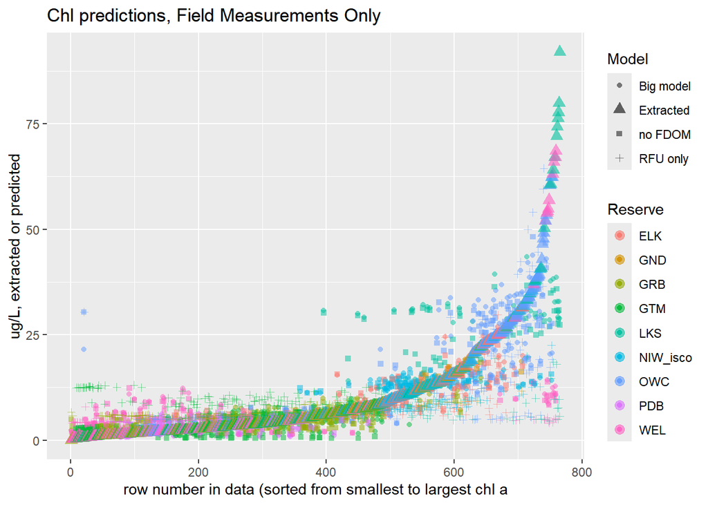

```r
ggplot(dat2, aes(x = rownum)) +
  geom_point(aes(y = preds_ols, shape = "Big model", color = reserve), alpha = 0.5) +
  geom_point(aes(y = preds_nofdom_ols, shape = "no FDOM", color = reserve), alpha = 0.5) +
  geom_point(aes(y = preds_rfu, shape = "RFU only", color = reserve), alpha = 0.5) +
  geom_point(aes(y = extracted, shape = "Extracted", color = reserve), size = 3, alpha = 0.6) +
  labs(title = "Chl predictions, Field Measurements Only",
       x = "row number in data (sorted from smallest to largest chl a",
       y = "ug/L, extracted or predicted",
       color = "Reserve",
       shape = "Model")
```

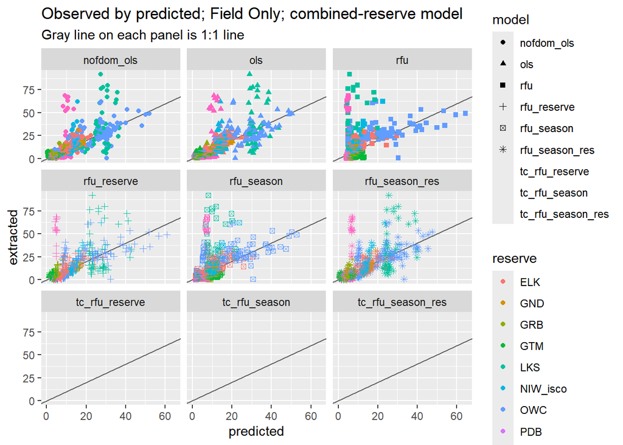

```r
ggplot(dat2_long) +
  geom_abline(slope = 1, intercept = 0, color = "gray40") +
  geom_point(aes(x = predicted, y = extracted, color = reserve, shape = model)) +
  facet_wrap(~model) +
  labs(title = "Observed by predicted; Field Only; combined-reserve model",
       subtitle = "Gray line on each panel is 1:1 line")
```

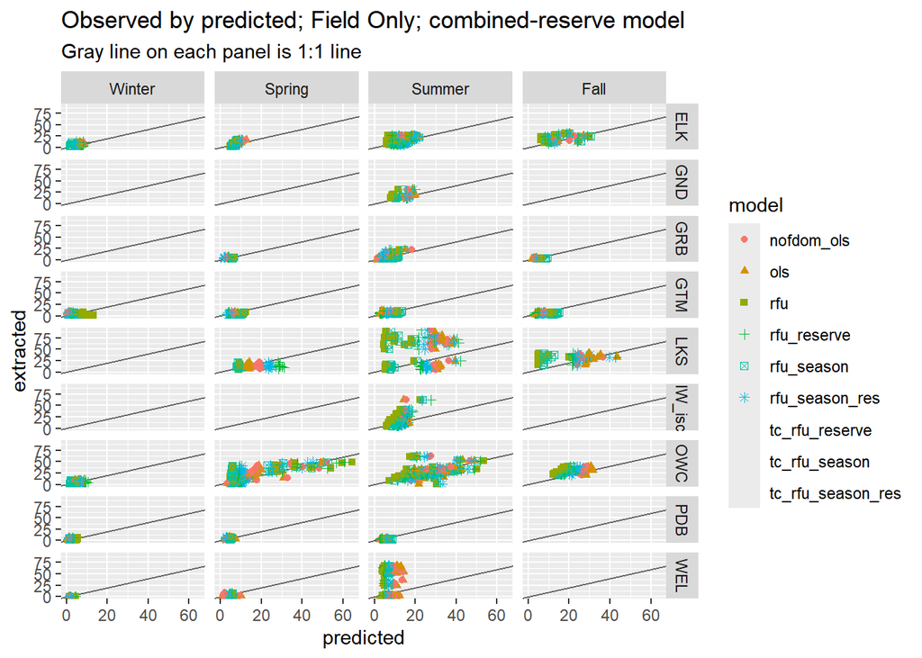

```r
ggplot(dat2_long) +
  geom_abline(slope = 1, intercept = 0, color = "gray40") +
  geom_point(aes(x = predicted, y = extracted, color = model, shape = model)) +
  facet_grid(reserve ~ season) +
  labs(title = "Observed by predicted; Field Only; combined-reserve model",
       subtitle = "Gray line on each panel is 1:1 line")
```

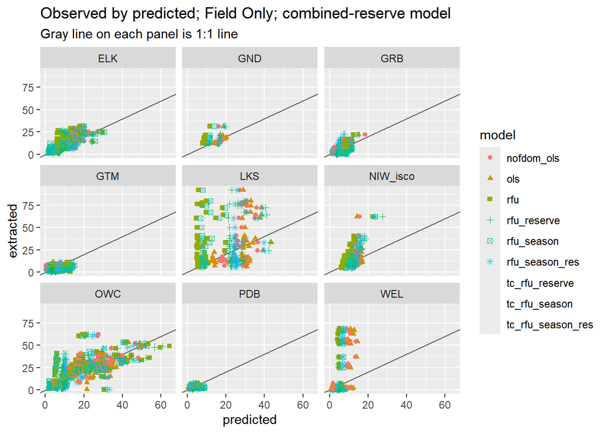

```r
ggplot(dat2_long) +
  geom_abline(slope = 1, intercept = 0, color = "gray40") +
  geom_point(aes(x = predicted, y = extracted, color = model, shape = model)) +
  facet_wrap(~reserve) +
  labs(title = "Observed by predicted; Field Only; combined-reserve model",
       subtitle = "Gray line on each panel is 1:1 line")
```

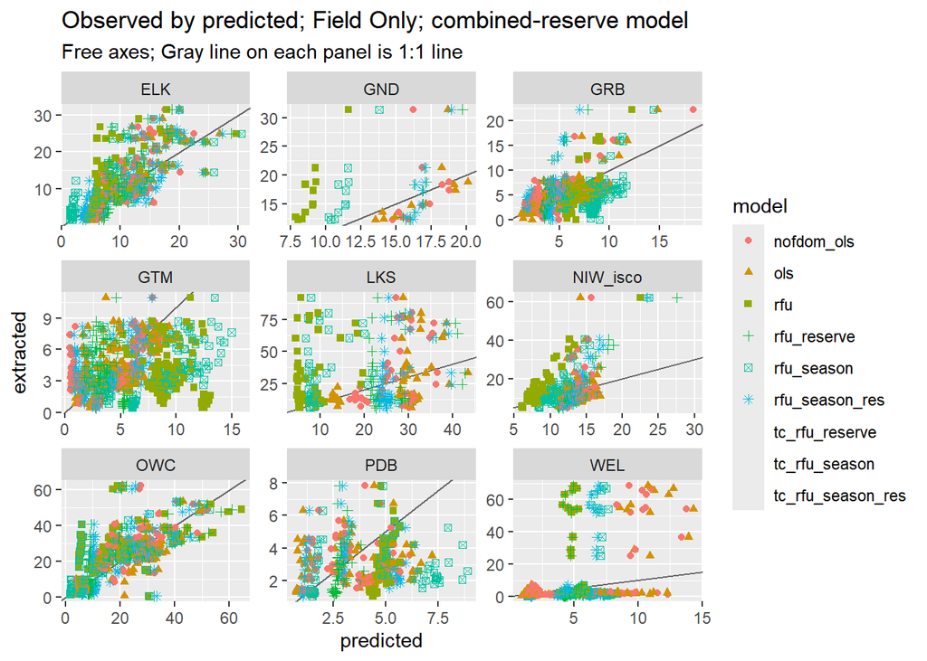

```r
ggplot(dat2_long) +
  geom_abline(slope = 1, intercept = 0, color = "gray40") +
  geom_point(aes(x = predicted, y = extracted, color = model, shape = model)) +
  facet_wrap(~reserve, scales = "free") +
  labs(title = "Observed by predicted; Field Only; combined-reserve model",
       subtitle = "Free axes; Gray line on each panel is 1:1 line")
```

```r
diags <- coeffs %>%
  select(model, AICc, R.2, prediction_error) %>%
  pivot_longer(-model, names_to = "diagnostic", values_to = "value") %>%
  mutate(diagnostic = case_when(diagnostic == "R.2" ~ "R^2",
                                diagnostic == "prediction_error" ~ "Prediction Error",
                                TRUE ~ diagnostic),
         model_type = case_when(stringr::str_starts(model, "rfu") ~ "RFU",
                                stringr::str_starts(model, "tc_rfu") ~ "TC-RFU",
                                TRUE ~ "multi-vars"))
```

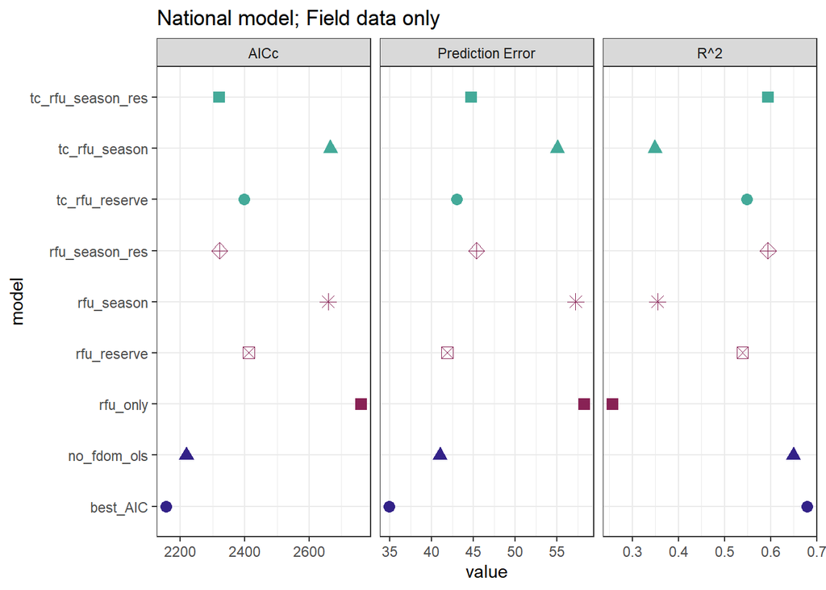

```r
# default will use max of 6 shapes. they are:
# 16, 17, 15, 3, 7, 8

my_shapes <- c(16, 17, 15, 7, 8, 9)

# colors below are from khroma::muted and are colorblind-friendly
# though that's not really necessary here because we also have shapes and names

ggplot(diags, aes(x = value, y = model)) +
  geom_point(size = 3, aes(color = model_type, shape = model)) +
  facet_wrap(~diagnostic, nrow = 1, scales = "free_x") +
  scale_shape_manual(values = rep(my_shapes, 2)) +
  scale_color_manual(values = c("#332288", "#882255", "#44AA99")) +
  theme_bw() +
  theme(legend.position = "none") +
  ggtitle("National model; Field data only")
```

```r
ggsave(here::here("model_coeffs", "diagnostics_multimodels_national_field.png"),
       width = 8, height = 4, units = "in")
```

You need reserve. Season helps, but primarily, you need reserve. Tweaking beyond that with temperature-correcting RFU, including turbidity and/or FDOM, etc., could improve things. But including ‘Reserve’ has the most impact on the model, repeatedly. So if you want a really good model, you have to put in some work to get the samples at your reserve.

# Models: Individual Reserves; Tank + ISCO

```r
load(here::here("data", "subset_no_NA.RData"))
table(dat$method)
```

```
##
## isco tank
##  765  311
```

```r
# dat <- filter(dat, method == "tank")

# original plot settings, for later
op <- par()

# options, for MuMIn operations
# will prevent fitting sub-models to different datasets (from help file)
options(na.action = "na.fail")
```

```r
dat$response <- sqrt(dat$extracted)
```

## Modeling: Individual Reserves, Tank + ISCO

Each of the models described below are fitted and evaluated using symmetric Median Absolute Percent Error.

**Full Model**

Includes all interactions between sensor_rfu, turbidity, and FDOM. Additionally, temp*rfu and temp*fdom. Hoping we can actually drop some of these.

**No FDOM**

If we drop FDOM and all its interactions, what do we get?

**RFU only**

This does *not* include reserve or season. If the other models above are better, reserve or season could still be the reason (vs. turbidity/temp/FDOM corrections). It would mean **local factors still have to be accounted for and modelled to get the most out of a TAL sensor**.

Using leave-one-out cross-validation due to low number of samples for some reserves and potential to introduce new factor levels on validation set.

```r
mod_sel_out <- list()
mod_summs_out <- list()
reserves <- unique(dat$reserve)
set.seed(1216)

for(i in seq_along(reserves)){
    res <- dat %>%
        filter(reserve == reserves[i])

    if(length(unique(res$season))>=2){

        full_ols <- glm(response ~ sensor_rfu + turb + fdom_qsu + sensor_rfu*turb*fdom_qsu + sensor_rfu*turb + sensor_rfu*fdom_qsu + turb*fdom_qsu + temp + sensor_rfu*temp + fdom_qsu*temp + season, data = res)
        no_fdom_ols <- glm(response ~ sensor_rfu + turb +  sensor_rfu*turb + temp + sensor_rfu*temp + season, data = res)
        no_fdom_lm <- lm(response ~ sensor_rfu + turb +  sensor_rfu*turb + temp + sensor_rfu*temp + season, data = res)

                           } else {

            full_ols <- glm(response ~ sensor_rfu + turb + fdom_qsu + sensor_rfu*turb*fdom_qsu + sensor_rfu*turb + sensor_rfu*fdom_qsu + turb*fdom_qsu + temp + sensor_rfu*temp + fdom_qsu*temp, data = res)

            no_fdom_ols <- glm(response ~ sensor_rfu + turb +  sensor_rfu*turb + temp + sensor_rfu*temp, data = res)
            no_fdom_lm <- lm(response ~ sensor_rfu + turb +  sensor_rfu*turb + temp + sensor_rfu*temp, data = res)
        }

    rfu_only <- glm(response ~ sensor_rfu, data = res)
    rfu_only_lm <- lm(response ~ sensor_rfu, data = res)

    sel <- dredge(full_ols,
                  fixed = "sensor_rfu",
                  extra = c("R^2", "AdjR^2" = function(x) summary(x)$adj.r.squared))

    # perform cross-validation on top model to find median prediction error
    ols.1 <- get.models(sel, 1)[[1]]
    ols.cv <- cv.glm(res, ols.1, cost)

    no_fdom.cv <- cv.glm(res, no_fdom_ols, cost)
    no_fdom.df <- data.frame(model.sel(no_fdom_ols))
    no_fdom.df$pred_test_error <- round(no_fdom.cv$delta[1], 2)

    rfu_only.cv <- cv.glm(res, rfu_only, cost)
    rfu_only.df <- data.frame(model.sel(rfu_only))
    rfu_only.df$pred_test_error <- round(rfu_only.cv$delta[1], 2)

    # pull out R^2s from lms (glms were run for cross-validation but really they're just regular linear models)
    no_fdom.df$R.2 <- round(summary(no_fdom_lm)$r.squared, 4)
    rfu_only.df$R.2 <- round(summary(rfu_only_lm)$r.squared, 4)


    # see anything with delta AICc < 2
    # subdf <- data.frame(subset(sel, delta < 2))

    # only top one
    subdf <- data.frame(sel[1])
    subdf$pred_test_error <- round(ols.cv$delta[1], 2)
    subdf <- subdf %>%
      bind_rows(no_fdom.df, rfu_only.df) %>%
      rownames_to_column(var = "model") %>%
      mutate(model = case_when(model == "...1" ~ "best_AIC",
                               TRUE ~ model)) %>%
      select(model, AICc, R.2, pred_test_error, everything()) %>%
      select(-c(delta, weight))

    # attach prediction error to it
    mod_sel_out[[i]] <- subdf

    # summary for top model
    mod_summs_out[[i]] <- summary(ols.1)


}
```

```r
mod_sel_out <- purrr::set_names(mod_sel_out, reserves)
mod_summs_out <- purrr::set_names(mod_summs_out, reserves)
```

## Summary Table

```r
mod_sel_df <- bind_rows(mod_sel_out, .id = "Reserve") %>%
  select(Reserve, model, AICc, R.2, prediction_error = pred_test_error,
         sensor_rfu, fdom_qsu, turb,
         season, temp, everything()) %>%
  mutate(across(c(AICc, prediction_error), round, 2),
           across(c(R.2, sensor_rfu, X.Intercept.), round, 3),
           across(c(fdom_qsu, turb, temp), round, 4),
           across(c(fdom_qsu.sensor_rfu:fdom_qsu.sensor_rfu.turb), round, 4) )


knitr::kable(mod_sel_df)
```

| Reserve | model | AICc | R.2 | prediction_error | sensor_rfu | fdom_qsu | turb | season | temp | X.Intercept. | fdom_qsu.sensor_rfu | fdom_qsu.temp | fdom_qsu.turb | sensor_rfu.temp | sensor_rfu.turb | fdom_qsu.sensor_rfu.turb | df | logLik |
| --- | --- | --- | --- | --- | --- | --- | --- | --- | --- | --- | --- | --- | --- | --- | --- | --- | --- | --- |
| ELK | best_AIC | 164.00 | 0.782 | 29.31 | 0.365 | 0.0242 | -0.0201 | + | 0.2324 | -1.216 | -0.0120 | NA | NA | NA | NA | NA | 10 | -70.6573286 |
| ELK | no_fdom_ols | 167.15 | 0.775 | 29.86 | 0.497 | NA | 0.0247 | + | 0.2605 | -1.448 | NA | NA | NA | -0.0105 | -0.0166 | NA | 10 | -72.2324976 |
| ELK | rfu_only | 219.10 | 0.531 | 39.18 | 0.410 | NA | NA | NA | NA | 2.161 | NA | NA | NA | NA | NA | NA | 3 | -106.4168089 |
| GND | best_AIC | 16.05 | 0.936 | 14.57 | 4.200 | 0.1017 | 0.0427 | + | NA | -6.832 | -0.0431 | NA | NA | NA | NA | NA | 7 | 3.2829289 |
| GND | no_fdom_ols | 28.46 | 0.911 | 23.63 | -4.397 | NA | 0.2064 | + | -0.6491 | 15.283 | NA | NA | NA | 0.2435 | -0.0709 | NA | 8 | -0.2317339 |
| GND | rfu_only | 19.89 | 0.842 | 18.12 | 1.569 | NA | NA | NA | NA | -0.488 | NA | NA | NA | NA | NA | NA | 3 | -6.2386236 |
| GTM | best_AIC | 218.52 | 0.801 | 37.36 | 0.270 | -0.0101 | -0.0325 | + | 0.0336 | 1.999 | NA | NA | NA | -0.0152 | 0.0118 | NA | 11 | -97.4505986 |
| GTM | no_fdom_ols | 268.40 | 0.731 | 40.07 | 0.143 | NA | -0.0671 | + | 0.0260 | 1.340 | NA | NA | NA | -0.0143 | 0.0235 | NA | 10 | -123.5309857 |
| GTM | rfu_only | 398.79 | 0.383 | 54.22 | 0.278 | NA | NA | NA | NA | 1.151 | NA | NA | NA | NA | NA | NA | 3 | -196.3250823 |
| LKS | best_AIC | 400.05 | 0.467 | 33.69 | -0.438 | 0.0036 | NA | NA | 0.3453 | 1.776 | 0.0104 | -0.0034 | NA | NA | NA | NA | 7 | -192.5466981 |
| LKS | no_fdom_ols | 432.81 | 0.332 | 38.19 | -0.158 | NA | -0.5230 | + | 0.0478 | 5.139 | NA | NA | NA | -0.0149 | 0.1323 | NA | 9 | -206.6204001 |
| LKS | rfu_only | 462.74 | 0.056 | 44.90 | 0.254 | NA | NA | NA | NA | 3.821 | NA | NA | NA | NA | NA | NA | 3 | -228.2714965 |
| NIW_isco | best_AIC | 71.22 | 0.866 | 16.52 | 4.453 | 0.0240 | 0.0137 | NA | 0.1247 | -4.938 | NA | NA | NA | -0.1174 | NA | NA | 7 | -27.7355066 |
| NIW_isco | no_fdom_ols | 96.52 | 0.810 | 19.76 | 3.762 | NA | 0.0106 | NA | 0.0976 | -1.924 | NA | NA | NA | -0.0979 | 0.0034 | NA | 7 | -40.3867257 |
| NIW_isco | rfu_only | 102.31 | 0.766 | 20.54 | 0.922 | NA | NA | NA | NA | 1.313 | NA | NA | NA | NA | NA | NA | 3 | -47.9801466 |
| OWC | best_AIC | 287.83 | 0.862 | 26.37 | 0.265 | 0.0058 | -0.0078 | + | 0.1618 | 1.433 | -0.0050 | 0.0014 | NA | NA | 0.0047 | NA | 12 | -130.5809124 |
| OWC | no_fdom_ols | 295.83 | 0.848 | 24.83 | 0.088 | NA | -0.0051 | + | 0.2449 | 1.556 | NA | NA | NA | -0.0042 | 0.0038 | NA | 10 | -136.9895356 |
| OWC | rfu_only | 437.02 | 0.491 | 54.08 | 0.296 | NA | NA | NA | NA | 2.731 | NA | NA | NA | NA | NA | NA | 3 | -215.4171941 |
| PDB | best_AIC | 1.33 | 0.846 | 19.65 | 1.100 | 0.0222 | 0.1228 | + | 0.0626 | -0.026 | NA | NA | NA | -0.0356 | -0.0855 | NA | 11 | 12.2220724 |
| PDB | no_fdom_ols | 2.08 | 0.839 | 20.41 | 1.096 | NA | 0.1282 | + | 0.0670 | 0.159 | NA | NA | NA | -0.0350 | -0.0834 | NA | 10 | 10.5101082 |
| PDB | rfu_only | 66.63 | 0.567 | 33.88 | 0.567 | NA | NA | NA | NA | 1.260 | NA | NA | NA | NA | NA | NA | 3 | -30.1620698 |
| WEL | best_AIC | 307.19 | 0.420 | 109.97 | 0.223 | -0.0665 | NA | NA | 0.1409 | 0.198 | NA | 0.0051 | NA | NA | NA | NA | 6 | -146.9797644 |
| WEL | no_fdom_ols | 312.19 | 0.439 | 115.92 | 3.126 | NA | 0.0057 | + | 0.4603 | -2.051 | NA | NA | NA | -0.2025 | -0.0797 | NA | 9 | -145.7123905 |
| WEL | rfu_only | 340.46 | 0.009 | 116.06 | 0.472 | NA | NA | NA | NA | 1.889 | NA | NA | NA | NA | NA | NA | 3 | -167.0627386 |
| GRB | best_AIC | 109.40 | 0.912 | 24.09 | -0.943 | -0.0147 | 0.0137 | + | -0.0383 | 2.703 | 0.0039 | NA | NA | 0.0603 | NA | NA | 10 | -43.8655083 |
| GRB | no_fdom_ols | 188.79 | 0.845 | 35.05 | -1.700 | NA | 0.0565 | + | -0.2114 | 4.942 | NA | NA | NA | 0.1124 | -0.0117 | NA | 9 | -84.7182453 |
| GRB | rfu_only | 278.53 | 0.681 | 44.01 | 0.471 | NA | NA | NA | NA | 1.301 | NA | NA | NA | NA | NA | NA | 3 | -136.1764757 |
| HEE_w2 | best_AIC | -286.34 | 1.000 | 57.91 | -8.174 | 0.0287 | -0.4635 | NA | NA | 7.383 | NA | NA | NA | NA | NA | NA | 5 | 133.1678783 |
| HEE_w2 | no_fdom_ols | -277.99 | 1.000 | 36.50 | -7.889 | NA | -0.4677 | NA | -0.0920 | 11.550 | NA | NA | NA | NA | NA | NA | 5 | 128.9938354 |
| HEE_w2 | rfu_only | Inf | 0.020 | 29.38 | -0.320 | NA | NA | NA | NA | 1.003 | NA | NA | NA | NA | NA | NA | 3 | 5.1344901 |
| HEE | best_AIC | -13.36 | 0.682 | 27.40 | 1.780 | 0.0204 | NA | NA | NA | 0.329 | -0.0711 | NA | NA | NA | NA | NA | 5 | 13.0444593 |
| HEE | no_fdom_ols | 2.16 | 0.731 | 40.96 | -9.132 | NA | -0.1212 | + | -0.1110 | 3.393 | NA | NA | NA | 0.3597 | 0.5268 | NA | 10 | 15.3883698 |
| HEE | rfu_only | -6.92 | 0.508 | 32.98 | 0.611 | NA | NA | NA | NA | 0.613 | NA | NA | NA | NA | NA | NA | 3 | 6.9589987 |
| MAR | best_AIC | 26.65 | 0.895 | 23.35 | 1.046 | NA | NA | NA | 0.0521 | 0.630 | NA | NA | NA | NA | NA | NA | 4 | -7.6566715 |
| MAR | no_fdom_ols | 54.27 | 0.920 | 26.94 | 0.301 | NA | -0.0101 | + | 0.0472 | 0.757 | NA | NA | NA | 0.0203 | 0.0146 | NA | 9 | -5.2779044 |
| MAR | rfu_only | 26.81 | 0.870 | 22.38 | 1.079 | NA | NA | NA | NA | 1.959 | NA | NA | NA | NA | NA | NA | 3 | -9.4825540 |
| NIW | best_AIC | 10.66 | 0.972 | 12.74 | 2.316 | -0.0111 | 0.0316 | + | 0.0058 | 0.524 | -0.0072 | 0.0015 | -5e-04 | -0.0386 | NA | NA | 12 | 9.6693095 |
| NIW | no_fdom_ols | 51.41 | 0.941 | 17.79 | 1.697 | NA | 0.0189 | + | 0.1003 | -0.325 | NA | NA | NA | -0.0388 | 0.0010 | NA | 9 | -15.0673806 |
| NIW | rfu_only | 89.74 | 0.865 | 23.58 | 1.158 | NA | NA | NA | NA | 1.535 | NA | NA | NA | NA | NA | NA | 3 | -41.6709946 |
| SAP | best_AIC | 141.16 | 0.561 | 53.51 | 1.146 | NA | 0.1303 | + | NA | 0.195 | NA | NA | NA | NA | -0.0346 | NA | 7 | -62.1042967 |
| SAP | no_fdom_ols | 145.89 | 0.574 | 56.58 | 1.058 | NA | 0.1482 | + | 0.0965 | -1.384 | NA | NA | NA | 0.0074 | -0.0390 | NA | 9 | -61.4444324 |
| SAP | rfu_only | 162.66 | 0.122 | 64.05 | 0.248 | NA | NA | NA | NA | 2.490 | NA | NA | NA | NA | NA | NA | 3 | -78.0457647 |

```r
write.csv(mod_sel_df, file = here::here("model_coeffs",                                     "IndRes_TankAndISCO.csv"), row.names = FALSE)
```

# Models: Individual Reserves; Tank Only

```r
load(here::here("data", "subset_no_NA.RData"))
table(dat$method)
```

```
##
## isco tank
##  765  311
```

```r
dat_isco <- filter(dat, method == "isco")
dat <- filter(dat, method == "tank")

# subset isco data to only reserves that also have tank data
dat_isco <- dat_isco %>%
  filter(reserve %in% unique(dat$reserve))

# original plot settings, for later
op <- par()

# options, for MuMIn operations
# will prevent fitting sub-models to different datasets (from help file)
options(na.action = "na.fail")
```

```r
dat$response <- sqrt(dat$extracted)
```

## Modeling: Individual Reserves, Tank Only

Each of the models described below are fitted and evaluated using symmetric Median Absolute Percent Error.

**Full Model**

Includes all interactions between sensor_rfu, turbidity, and FDOM. Additionally, temp*rfu and temp*fdom. Hoping we can actually drop some of these.

**No FDOM**

If we drop FDOM and all its interactions, what do we get?

**RFU only**

This does *not* include reserve or season. If the other models above are better, reserve or season could still be the reason (vs. turbidity/temp/FDOM corrections). It would mean **local factors still have to be accounted for and modelled to get the most out of a TAL sensor**.

**RFU + season**

**Temp-Corrected RFU + season**

Temp-corrected RFU is denoted as `tc_rfu` in the model names and objects. The correction was based on a global rho value which was the average of all individual rho values, as calculated by Hannah Ramage, from the temperature interference trials. This global rho value was then inserted into the equation from Watras et al. 2017 as follows:

Temp-corrected-RFU = original-RFU / (1 + global_rho*(temp_reading - 20))

Using leave-one-out cross-validation due to low number of samples for some reserves and potential to introduce new factor levels on validation set.

**Testing predictions on ISCO data**

Five reserves collected both tank and ISCO data: GND, GTM, LKS, PDB, GRB. (NIW is not included here because their ISCO data was collected at a different station than their tank data.)

```r
mod_sel_out <- list()
mod_summs_out <- list()
isco_preds_out <- list()
reserves <- unique(dat$reserve)
set.seed(1216)

for(i in seq_along(reserves)){
    res <- dat %>%
        filter(reserve == reserves[i])

    if(length(unique(res$season))>=2){
        #lots of variables
        full_ols <- glm(response ~ sensor_rfu + turb + fdom_qsu + sensor_rfu*turb*fdom_qsu + sensor_rfu*turb + sensor_rfu*fdom_qsu + turb*fdom_qsu + temp + sensor_rfu*temp + fdom_qsu*temp + season, data = res)
        # remove FDOM
        no_fdom_ols <- glm(response ~ sensor_rfu + turb +  sensor_rfu*turb + temp + sensor_rfu*temp + season, data = res)
        no_fdom_lm <- lm(response ~ sensor_rfu + turb +  sensor_rfu*turb + temp + sensor_rfu*temp + season, data = res)
        # only rfu + season
        rfu_season <- glm(response ~ sensor_rfu + season, data = res)
        rfu_season_lm <- lm(response ~ sensor_rfu + season, data = res)
        # cross-validate
        rfu_season.cv <- cv.glm(res, rfu_season, cost)
        rfu_season.df <- data.frame(model.sel(rfu_season))
        rfu_season.df$pred_test_error <- round(rfu_season.cv$delta[1], 2)
        rfu_season.df$R.2 <- round(summary(rfu_season_lm)$r.squared, 4)
        # temp-corrected rfu + season
        tc_rfu_season <- glm(response ~ rfu_temp_corrected + season, data = res)
        tc_rfu_season_lm <- lm(response ~ rfu_temp_corrected + season, data = res)
        # cross-validate
        tc_rfu_season.cv <- cv.glm(res, tc_rfu_season, cost)
        tc_rfu_season.df <- data.frame(model.sel(tc_rfu_season))
        tc_rfu_season.df$pred_test_error <- round(tc_rfu_season.cv$delta[1], 2)
        tc_rfu_season.df$R.2 <- round(summary(tc_rfu_season_lm)$r.squared, 4)

                           } else {

            full_ols <- glm(response ~ sensor_rfu + turb + fdom_qsu + sensor_rfu*turb*fdom_qsu + sensor_rfu*turb + sensor_rfu*fdom_qsu + turb*fdom_qsu + temp + sensor_rfu*temp + fdom_qsu*temp, data = res)

            no_fdom_ols <- glm(response ~ sensor_rfu + turb +  sensor_rfu*turb + temp + sensor_rfu*temp, data = res)
            no_fdom_lm <- lm(response ~ sensor_rfu + turb +  sensor_rfu*turb + temp + sensor_rfu*temp, data = res)
        }

    rfu_only <- glm(response ~ sensor_rfu, data = res)
    rfu_only_lm <- lm(response ~ sensor_rfu, data = res)

    tc_rfu_only <- glm(response ~ rfu_temp_corrected, data = res)
    tc_rfu_only_lm <- lm(response ~ rfu_temp_corrected, data = res)

    sel <- dredge(full_ols,
                  fixed = "sensor_rfu",
                  extra = c("R^2", "AdjR^2" = function(x) summary(x)$adj.r.squared))

    # perform cross-validation on top model to find median prediction error
    ols.1 <- get.models(sel, 1)[[1]]
    ols.cv <- cv.glm(res, ols.1, cost)

    no_fdom.cv <- cv.glm(res, no_fdom_ols, cost)
    no_fdom.df <- data.frame(model.sel(no_fdom_ols))
    no_fdom.df$pred_test_error <- round(no_fdom.cv$delta[1], 2)

    rfu_only.cv <- cv.glm(res, rfu_only, cost)
    rfu_only.df <- data.frame(model.sel(rfu_only))
    rfu_only.df$pred_test_error <- round(rfu_only.cv$delta[1], 2)

    tc_rfu_only.cv <- cv.glm(res, tc_rfu_only, cost)
    tc_rfu_only.df <- data.frame(model.sel(tc_rfu_only))
    tc_rfu_only.df$pred_test_error <- round(tc_rfu_only.cv$delta[1], 2)

    # pull out R^2s from lms (glms were run for cross-validation but really they're just regular linear models)
    no_fdom.df$R.2 <- round(summary(no_fdom_lm)$r.squared, 4)
    rfu_only.df$R.2 <- round(summary(rfu_only_lm)$r.squared, 4)
    tc_rfu_only.df$R.2 <- round(summary(tc_rfu_only_lm)$r.squared, 4)


    ## BIND IT ALL TOGETHER

    # only top one
    subdf <- data.frame(sel[1])
    subdf$pred_test_error <- round(ols.cv$delta[1], 2)

    # if seasonal models exist, add them to this df
    if(length(unique(res$season))>=2){
      subdf <- subdf %>%
        bind_rows(rfu_season.df, tc_rfu_season.df)
    }

    # bind other data frames of output and format
    subdf <- subdf %>%
      bind_rows(no_fdom.df, rfu_only.df, tc_rfu_only.df) %>%
      rownames_to_column(var = "model") %>%
      mutate(model = case_when(model == "...1" ~ "best_AIC",
                               TRUE ~ model)) %>%
      select(model, AICc, R.2, pred_test_error, everything()) %>%
      select(-c(delta, weight))

    # attach prediction error to it
    mod_sel_out[[i]] <- subdf

    # summary for top model
    mod_summs_out[[i]] <- summary(ols.1)


    # ISCO predictions
    if(reserves[i] %in% unique(dat_isco$reserve)){
      isco <- dat_isco %>%
        filter(reserve == reserves[i],
               season %in% unique(res$season)) %>%
        mutate(preds_best_AIC = (predict(ols.1, newdata = .))^2,
               preds_no_fdom_ols = (predict(no_fdom_ols, newdata = .))^2,
               preds_rfu_only = (predict(rfu_only, newdata = .))^2)

      isco_preds_out[[i]] <- isco


    }


}
```

```r
mod_sel_out <- purrr::set_names(mod_sel_out, reserves)
mod_summs_out <- purrr::set_names(mod_summs_out, reserves)
isco_preds <- bind_rows(isco_preds_out)
isco_preds_long <- isco_preds %>%
  select(reserve, month, season, method, extracted, starts_with("preds")) %>%
  pivot_longer(cols = starts_with("preds"),
               names_to = "model",
               names_prefix = "preds_",
               values_to = "predicted")
```

## Summary Table

```r
mod_sel_df <- bind_rows(mod_sel_out, .id = "Reserve") %>%
  select(Reserve, model, AICc, R.2, prediction_error = pred_test_error,
         sensor_rfu, rfu_temp_corrected, fdom_qsu, turb,
         season, temp, everything()) %>%
  mutate(across(c(AICc, prediction_error), round, 2),
           across(c(R.2, sensor_rfu, rfu_temp_corrected, X.Intercept.), round, 3),
           across(c(fdom_qsu, turb, temp), round, 4),
           across(c(fdom_qsu.sensor_rfu:fdom_qsu.sensor_rfu.turb), round, 4) )


knitr::kable(mod_sel_df)
```

| Reserve | model | AICc | R.2 | prediction_error | sensor_rfu | rfu_temp_corrected | fdom_qsu | turb | season | temp | X.Intercept. | fdom_qsu.sensor_rfu | fdom_qsu.temp | fdom_qsu.turb | sensor_rfu.temp | sensor_rfu.turb | fdom_qsu.sensor_rfu.turb | df | logLik |
| --- | --- | --- | --- | --- | --- | --- | --- | --- | --- | --- | --- | --- | --- | --- | --- | --- | --- | --- | --- |
| GND | best_AIC | -748.83 | 1.000 | 45.68 | -2.952 | NA | 0.2398 | -1.4332 | NA | -0.4934 | 10.363 | -0.0845 | -0.0018 | 0.0033 | 0.2329 | 0.4522 | NA | 11 | 319.4172685 |
| GND | rfu_season | 21.42 | 0.821 | 28.66 | 1.755 | NA | NA | NA | + | NA | -0.975 | NA | NA | NA | NA | NA | NA | 4 | -2.7079477 |
| GND | tc_rfu_season | 26.92 | 0.690 | 38.08 | NA | 1.597 | NA | NA | + | NA | -0.762 | NA | NA | NA | NA | NA | NA | 4 | -5.4579357 |
| GND | no_fdom_ols | 159.92 | 0.897 | 56.14 | -6.190 | NA | NA | 0.1641 | + | -0.8080 | 20.103 | NA | NA | NA | 0.2996 | -0.0499 | NA | 8 | 0.0394562 |
| GND | rfu_only | 17.23 | 0.786 | 26.65 | 1.570 | NA | NA | NA | NA | NA | -0.612 | NA | NA | NA | NA | NA | NA | 3 | -3.6130760 |
| GND | tc_rfu_only | 21.80 | 0.661 | 34.46 | NA | 1.423 | NA | NA | NA | NA | -0.401 | NA | NA | NA | NA | NA | NA | 3 | -5.9008905 |
| GRB | best_AIC | 27.53 | 0.977 | 28.15 | -0.961 | NA | 0.0118 | NA | NA | -0.0641 | 2.668 | NA | NA | NA | 0.0687 | NA | NA | 6 | -4.5358339 |
| GRB | rfu_season | 51.83 | 0.884 | 37.83 | 0.388 | NA | NA | NA | + | NA | 1.875 | NA | NA | NA | NA | NA | NA | 4 | -20.5801195 |
| GRB | tc_rfu_season | 49.88 | 0.895 | 35.84 | NA | 0.393 | NA | NA | + | NA | 1.846 | NA | NA | NA | NA | NA | NA | 4 | -19.6076483 |
| GRB | no_fdom_ols | 35.46 | 0.980 | 27.26 | -1.526 | NA | NA | 0.0887 | + | -0.1535 | 4.224 | NA | NA | NA | 0.1162 | -0.0626 | NA | 8 | -3.1856896 |
| GRB | rfu_only | 49.24 | 0.880 | 35.24 | 0.397 | NA | NA | NA | NA | NA | 1.981 | NA | NA | NA | NA | NA | NA | 3 | -20.8705743 |
| GRB | tc_rfu_only | 47.37 | 0.891 | 33.60 | NA | 0.402 | NA | NA | NA | NA | 1.952 | NA | NA | NA | NA | NA | NA | 3 | -19.9332260 |
| GTM | best_AIC | 32.21 | 0.917 | 20.32 | 0.292 | NA | NA | 0.0813 | NA | NA | 0.880 | NA | NA | NA | NA | NA | NA | 4 | -11.3374919 |
| GTM | rfu_season | 40.57 | 0.910 | 22.95 | 0.285 | NA | NA | NA | + | NA | 1.128 | NA | NA | NA | NA | NA | NA | 6 | -12.5336194 |
| GTM | tc_rfu_season | 42.29 | 0.905 | 24.05 | NA | 0.315 | NA | NA | + | NA | 1.183 | NA | NA | NA | NA | NA | NA | 6 | -13.3958336 |
| GTM | no_fdom_ols | 50.50 | 0.925 | 25.93 | 0.243 | NA | NA | 0.0059 | + | 0.0019 | 1.157 | NA | NA | NA | -0.0005 | 0.0063 | NA | 10 | -9.7484209 |
| GTM | rfu_only | 47.16 | 0.853 | 25.19 | 0.332 | NA | NA | NA | NA | NA | 1.303 | NA | NA | NA | NA | NA | NA | 3 | -20.1353551 |
| GTM | tc_rfu_only | 46.34 | 0.857 | 24.59 | NA | 0.365 | NA | NA | NA | NA | 1.342 | NA | NA | NA | NA | NA | NA | 3 | -19.7239209 |
| HEE_w2 | best_AIC | -286.34 | 1.000 | 57.91 | -8.174 | NA | 0.0287 | -0.4635 | NA | NA | 7.383 | NA | NA | NA | NA | NA | NA | 5 | 133.1678783 |
| HEE_w2 | no_fdom_ols | -277.99 | 1.000 | 36.50 | -7.889 | NA | NA | -0.4677 | NA | -0.0920 | 11.550 | NA | NA | NA | NA | NA | NA | 5 | 128.9938354 |
| HEE_w2 | rfu_only | Inf | 0.020 | 29.38 | -0.320 | NA | NA | NA | NA | NA | 1.003 | NA | NA | NA | NA | NA | NA | 3 | 5.1344901 |
| HEE_w2 | tc_rfu_only | Inf | 0.002 | 28.04 | NA | -0.096 | NA | NA | NA | NA | 0.901 | NA | NA | NA | NA | NA | NA | 3 | 5.0968492 |
| HEE | best_AIC | -13.36 | 0.682 | 27.40 | 1.780 | NA | 0.0204 | NA | NA | NA | 0.329 | -0.0711 | NA | NA | NA | NA | NA | 5 | 13.0444593 |
| HEE | rfu_season | -2.60 | 0.584 | 30.53 | 0.525 | NA | NA | NA | + | NA | 0.527 | NA | NA | NA | NA | NA | NA | 6 | 9.2986788 |
| HEE | tc_rfu_season | -2.88 | 0.588 | 30.70 | NA | 0.499 | NA | NA | + | NA | 0.527 | NA | NA | NA | NA | NA | NA | 6 | 9.4417755 |
| HEE | no_fdom_ols | 2.16 | 0.731 | 40.96 | -9.132 | NA | NA | -0.1212 | + | -0.1110 | 3.393 | NA | NA | NA | 0.3597 | 0.5268 | NA | 10 | 15.3883698 |
| HEE | rfu_only | -6.92 | 0.508 | 32.98 | 0.611 | NA | NA | NA | NA | NA | 0.613 | NA | NA | NA | NA | NA | NA | 3 | 6.9589987 |
| HEE | tc_rfu_only | -7.12 | 0.512 | 32.82 | NA | 0.579 | NA | NA | NA | NA | 0.610 | NA | NA | NA | NA | NA | NA | 3 | 7.0588119 |
| LKS | best_AIC | 108.77 | 0.824 | 19.93 | -0.892 | NA | 0.0252 | 0.1109 | + | 0.2942 | 0.672 | 0.0065 | -0.0024 | -0.0024 | NA | 0.0857 | NA | 11 | -41.3545756 |
| LKS | rfu_season | 156.99 | 0.587 | 26.41 | 0.689 | NA | NA | NA | + | NA | 1.806 | NA | NA | NA | NA | NA | NA | 4 | -74.2172200 |
| LKS | tc_rfu_season | 158.72 | 0.577 | 26.66 | NA | 0.657 | NA | NA | + | NA | 2.091 | NA | NA | NA | NA | NA | NA | 4 | -75.0846102 |
| LKS | no_fdom_ols | 156.21 | 0.639 | 25.61 | 0.186 | NA | NA | -0.4026 | + | 0.0591 | 3.697 | NA | NA | NA | -0.0237 | 0.1199 | NA | 8 | -69.0446347 |
| LKS | rfu_only | 156.35 | 0.578 | 26.57 | 0.686 | NA | NA | NA | NA | NA | 1.942 | NA | NA | NA | NA | NA | NA | 3 | -75.0103832 |
| LKS | tc_rfu_only | 156.58 | 0.577 | 26.34 | NA | 0.655 | NA | NA | NA | NA | 2.070 | NA | NA | NA | NA | NA | NA | 3 | -75.1231395 |
| MAR | best_AIC | 26.65 | 0.895 | 23.35 | 1.046 | NA | NA | NA | NA | 0.0521 | 0.630 | NA | NA | NA | NA | NA | NA | 4 | -7.6566715 |
| MAR | rfu_season | 27.21 | 0.915 | 18.68 | 0.995 | NA | NA | NA | + | NA | 1.383 | NA | NA | NA | NA | NA | NA | 5 | -5.8763327 |
| MAR | tc_rfu_season | 26.94 | 0.916 | 18.68 | NA | 0.899 | NA | NA | + | NA | 1.470 | NA | NA | NA | NA | NA | NA | 5 | -5.7426097 |
| MAR | no_fdom_ols | 54.27 | 0.920 | 26.94 | 0.301 | NA | NA | -0.0101 | + | 0.0472 | 0.757 | NA | NA | NA | 0.0203 | 0.0146 | NA | 9 | -5.2779044 |
| MAR | rfu_only | 26.81 | 0.870 | 22.38 | 1.079 | NA | NA | NA | NA | NA | 1.959 | NA | NA | NA | NA | NA | NA | 3 | -9.4825540 |
| MAR | tc_rfu_only | 25.69 | 0.878 | 21.60 | NA | 0.981 | NA | NA | NA | NA | 1.971 | NA | NA | NA | NA | NA | NA | 3 | -8.9205896 |
| NIW | best_AIC | 10.66 | 0.972 | 12.74 | 2.316 | NA | -0.0111 | 0.0316 | + | 0.0058 | 0.524 | -0.0072 | 0.0015 | -0.0005 | -0.0386 | NA | NA | 12 | 9.6693095 |
| NIW | rfu_season | 77.87 | 0.895 | 21.75 | 0.994 | NA | NA | NA | + | NA | 1.457 | NA | NA | NA | NA | NA | NA | 5 | -33.4254128 |
| NIW | tc_rfu_season | 79.06 | 0.893 | 21.78 | NA | 0.870 | NA | NA | + | NA | 1.656 | NA | NA | NA | NA | NA | NA | 5 | -34.0195410 |
| NIW | no_fdom_ols | 51.41 | 0.941 | 17.79 | 1.697 | NA | NA | 0.0189 | + | 0.1003 | -0.325 | NA | NA | NA | -0.0388 | 0.0010 | NA | 9 | -15.0673806 |
| NIW | rfu_only | 89.74 | 0.865 | 23.58 | 1.158 | NA | NA | NA | NA | NA | 1.535 | NA | NA | NA | NA | NA | NA | 3 | -41.6709946 |
| NIW | tc_rfu_only | 84.56 | 0.875 | 23.04 | NA | 0.989 | NA | NA | NA | NA | 1.725 | NA | NA | NA | NA | NA | NA | 3 | -39.0816008 |
| PDB | best_AIC | -1031.87 | 1.000 | 92.60 | 0.904 | NA | -0.2145 | -2.8195 | + | -0.1531 | 3.545 | -0.1305 | 0.0271 | 0.1334 | NA | -0.2515 | 0.1688 | 14 | 424.9350912 |
| PDB | rfu_season | 4.72 | 0.987 | 13.44 | 0.559 | NA | NA | NA | + | NA | 0.752 | NA | NA | NA | NA | NA | NA | 6 | 10.6392148 |
| PDB | tc_rfu_season | 2.75 | 0.988 | 13.18 | NA | 0.613 | NA | NA | + | NA | 0.762 | NA | NA | NA | NA | NA | NA | 6 | 11.6242223 |
| PDB | no_fdom_ols | 102.70 | 0.992 | 49.48 | 0.361 | NA | NA | -0.0390 | + | 0.0292 | 0.554 | NA | NA | NA | 0.0122 | 0.1219 | NA | 10 | 13.6491386 |
| PDB | rfu_only | 6.44 | 0.941 | 23.42 | 0.643 | NA | NA | NA | NA | NA | 0.951 | NA | NA | NA | NA | NA | NA | 3 | 1.1133777 |
| PDB | tc_rfu_only | 5.03 | 0.947 | 22.16 | NA | 0.699 | NA | NA | NA | NA | 0.948 | NA | NA | NA | NA | NA | NA | 3 | 1.8160080 |
| SAP | best_AIC | 141.16 | 0.561 | 53.51 | 1.146 | NA | NA | 0.1303 | + | NA | 0.195 | NA | NA | NA | NA | -0.0346 | NA | 7 | -62.1042967 |
| SAP | rfu_season | 162.95 | 0.207 | 62.42 | 0.244 | NA | NA | NA | + | NA | 2.718 | NA | NA | NA | NA | NA | NA | 5 | -75.7235401 |
| SAP | tc_rfu_season | 163.68 | 0.194 | 63.00 | NA | 0.197 | NA | NA | + | NA | 2.840 | NA | NA | NA | NA | NA | NA | 5 | -76.0916639 |
| SAP | no_fdom_ols | 145.89 | 0.574 | 56.58 | 1.058 | NA | NA | 0.1482 | + | 0.0965 | -1.384 | NA | NA | NA | 0.0074 | -0.0390 | NA | 9 | -61.4444324 |
| SAP | rfu_only | 162.66 | 0.122 | 64.05 | 0.248 | NA | NA | NA | NA | NA | 2.490 | NA | NA | NA | NA | NA | NA | 3 | -78.0457647 |
| SAP | tc_rfu_only | 163.20 | 0.112 | 64.62 | NA | 0.204 | NA | NA | NA | NA | 2.605 | NA | NA | NA | NA | NA | NA | 3 | -78.3143999 |

```r
write.csv(mod_sel_df, file = here::here("model_coeffs",                                     "IndRes_TankOnly.csv"), row.names = FALSE)
```

# Graph of model diagnostics by reserve

```r
diags <- mod_sel_df %>%
  select(Reserve, model, AICc, R.2, prediction_error) %>%
  pivot_longer(-c(Reserve, model), names_to = "diagnostic", values_to = "value") %>%
  mutate(diagnostic = case_when(diagnostic == "R.2" ~ "R^2",
                                diagnostic == "prediction_error" ~ "Prediction Error",
                                TRUE ~ diagnostic),
         model_type = case_when(stringr::str_starts(model, "rfu") ~ "RFU",
                                stringr::str_starts(model, "tc_rfu") ~ "TC-RFU",
                                TRUE ~ "multi-vars"))
```

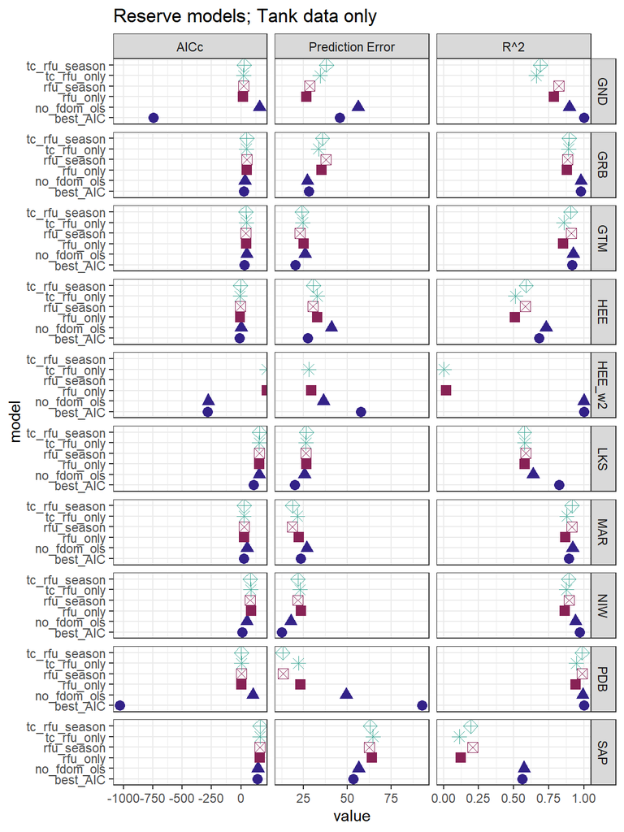

```r
my_shapes <- c(16, 17, 15, 7, 8, 9)

# colors below are from khroma::muted and are colorblind-friendly
# though that's not really necessary here because we also have shapes and names

ggplot(diags, aes(x = value, y = model)) +
  geom_point(size = 3, aes(color = model_type, shape = model)) +
  facet_grid(Reserve~diagnostic, scales = "free_x") +
  scale_shape_manual(values = rep(my_shapes, 2)) +
  scale_color_manual(values = c("#332288", "#882255", "#44AA99")) +
  theme_bw() +
  theme(legend.position = "none") +
  ggtitle("Reserve models; Tank data only")
```

Get rid of GND and PDB due to that massive overfitting that messes up the AICc scale, and also HEE_w2 because it was such a small sample size.

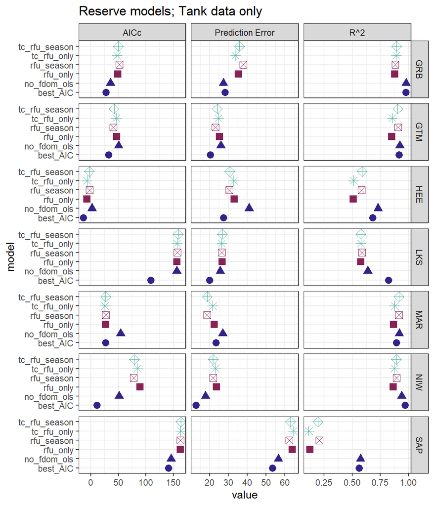

```r
diags %>%
  filter(!(Reserve %in% c("GND", "PDB", "HEE_w2"))) %>%
ggplot(aes(x = value, y = model)) +
  geom_point(size = 3, aes(color = model_type, shape = model)) +
  facet_grid(Reserve~diagnostic, scales = "free_x") +
  scale_shape_manual(values = rep(my_shapes, 2)) +
  scale_color_manual(values = c("#332288", "#882255", "#44AA99")) +
  theme_bw() +
  theme(legend.position = "none") +
  ggtitle("Reserve models; Tank data only")
```

Same thing, but also get rid of temp-corrected RFU because it adds clutter.

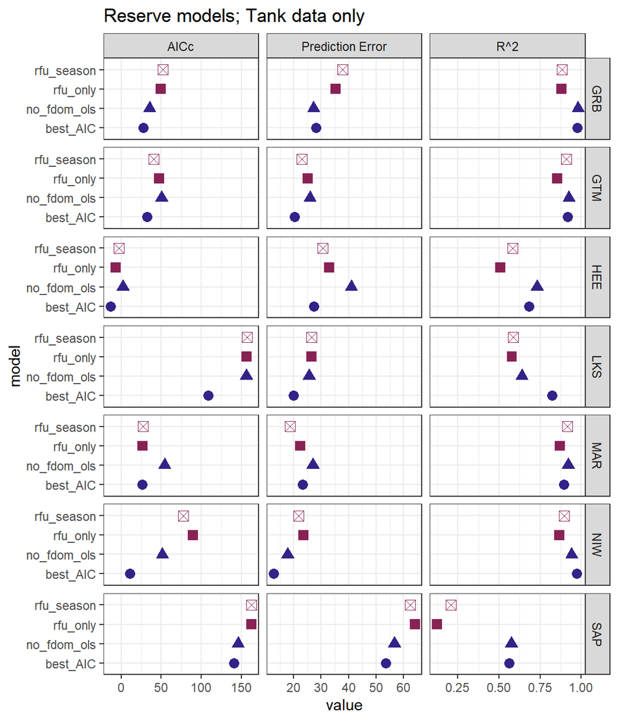

```r
diags %>%
  filter(!(Reserve %in% c("GND", "PDB", "HEE_w2")),
         !(model %in% c("tc_rfu_season", "tc_rfu_only"))) %>%
ggplot(aes(x = value, y = model)) +
  geom_point(size = 3, aes(color = model_type, shape = model)) +
  facet_grid(Reserve~diagnostic, scales = "free_x") +
  scale_shape_manual(values = rep(my_shapes, 2)) +
  scale_color_manual(values = c("#332288", "#882255", "#44AA99")) +
  theme_bw() +
  theme(legend.position = "none") +
  ggtitle("Reserve models; Tank data only")
```

```r
ggsave(here::here("model_figures",
                  "IndRes_TankOnly_4Mods_diagnostics.png"),
       width = 6, height = 7, units = "in")
```

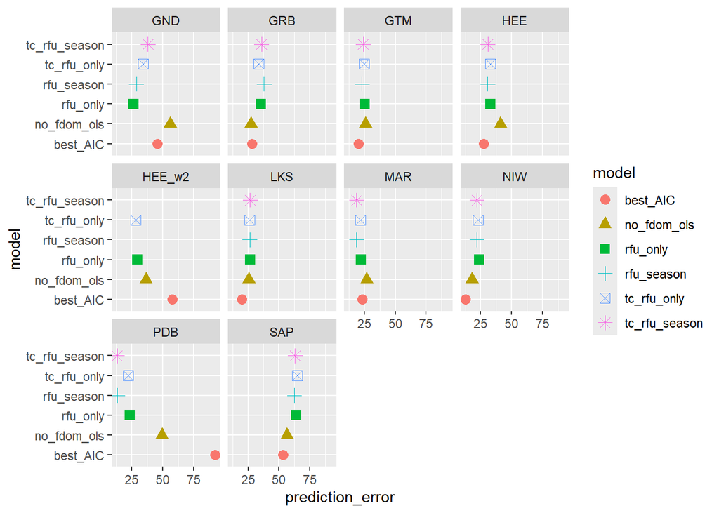

```r
ggplot(mod_sel_df, aes(x = prediction_error, y = model,
                       color = model, shape = model)) +
  geom_point(size = 3) +
  facet_wrap(~Reserve)
```